# COVID-19 Vaccine Demographics Analysis

# By: Hailey Dusablon and Jordan Stein

## Project Goals:

The goal of this project is to use Data Science technique used in class to examine data sets about COVID vaccination in the US. So far, we have gathered our data, created a project plan and a collaboration plan, and tidied our data to prepare it for use.

## Questions Being Investigated:

1. How do socioeconomic factors, such as poverty, income, and education affect the rate of vaccination at the state and county level in the United States?
2. Do regions with low COVID vaccine rates also have low rates for other types of common vaccines, such as MMR, HPV, and Flu vaccines.

In this analysis, the COVID vaccine rates for each location will be the dependent variables, and various social factors will serve as independent variables.

## Links:

https://github.com/hduece/finaltutorial

https://hduece.github.io/finaltutorial/

## Project Description

As partners (Hailey Dusablon and Jordan Stein), we are interested in exploring socioeconomic factors that may be correlated to health issues. Since we are both interested in careers in the healthcare field, analyzing this type of data would be a great opportunity to gain some insight into how lifestyle factors may affect the health of populations. This type of research is important because lifestyle choices can be changed, so it is useful to know how our everyday actions can impact our health. The first dataset we are interested in analyzing is the COVID Data Tracker published by the CDC (which can be found here: https://covid.cdc.gov/covid-data-tracker/#datatracker-home). This dataset contains information related to the prevalence of covid cases, deaths, and trends at the national, state, and county levels in the United States. More specifically, this dataset contains information regarding the state-wide distribution of people who have received the COVID vaccine. One question that would be interesting to explore with this data is how socioeconomic factors, such as poverty and minority group distribution, affect the spread of covid and the vaccination rates in different states and counties. We would also like to see if the regions with lower rates of the covid vaccine also have lower rates of other types of common vaccines. Since there is a significant stigma surrounding the COVID vaccine, it would be interesting to see how the COVID vaccine rates compare to other vaccine rates. Lastly, we could compare the COVID trends in the United States to trends in other countries by including some research about how other health officials handled the spread of the virus, and this may be useful for looking at socioeconomic factors since they will likely differ depending on the country. We are considering this research because COVID has been a very relevant problem for the past year and a half and the COVID vaccine has been very controversial. We have not seen a lot of covid research studying social factors such as religion, access to healthcare resources, and income.

## Collaboration Plan:

To begin the project, we started by setting up a Github repository and ensuring that we were both listed as collaborators. Since the website was created with Hailey’s account, Jordan cloned the repository on her computer. After this website was established, we met on Zoom to discuss datasets we were interested in exploring and possible ideas about how we would analyze these datasets. For future collaboration, we are planning to meet twice a week on Tuesdays and Thursdays for two hours each day via Zoom or in-person and will be coordinating code through a private Github repository.

# References

1. https://covid.cdc.gov/covid-data-tracker/#datatracker-home : State-level data for COVID Vaccines
2. https://data.cdc.gov/Vaccinations/COVID-19-Vaccinations-in-the-United-States-County/8xkx-amqh : County-level data for COVID Vaccines
3. https://worldpopulationreview.com/state-rankings/median-household-income-by-state : Median Household Income by State for 2021
4. https://www.bea.gov/data/gdp/gdp-county-metro-and-other-areas : County GDP
5. https://corgis-edu.github.io/corgis/csv/state_demographics/ : State Demographics (Education, Employment, Ethnicity)
6. https://www.openintro.org/data/?data=county_complete : County Demographics (Education, Employment, Ethnicity)
7. https://data.cdc.gov/Public-Health-Surveillance/United-States-COVID-19-County-Level-of-Community-T/8396-v7yb : COVID-19 transmission data per county

# Part 1: Analysis of COVID Vaccines at the State Level

Part 1 Description: The following DataFrame contains information regarding the number of people vaccinated in each state in the United States. It contains information about the distrbution of the three different available vaccines (Moderna, Pfizer, and Janssen) and the number of doses people in each state have received. There is also data regarding vaccine rates for the 65+ age group, since this age group is a high-risk group for the virus. This data can be compared to the socio-economic patterns in each state to see if any of these factors are correlated with vaccine rates.

```python
#Set up pandas and import our CSV files to DataFrames:
import pandas as pd
pd.DataFrame
vac_state = pd.read_csv("./data/vaccine_state.csv")
vac_county = pd.read_csv("./data/Vaccine_county.csv")
stats = pd.read_csv("./data/countystats.csv")
trans = pd.read_csv("./data/county_transmission.csv")
gdp = pd.read_csv("./data/county_gdp.csv")
state_income_df = pd.read_csv("./data/StateIncome.csv")

#Get rid of max rows so whole dataframe can be examined, fix a few things about our data frame to make our lives easier:
pd.set_option('display.max_rows', None)
pd.set_option('display.max_columns', None)
vac_state = vac_state.set_index("State")
vac_state = vac_state.rename(index = {'New York State': "New York"})
vac_state = vac_state.drop(['United States'], axis = 0)
vac_state
```

| State | People with at least One Dose by State of Residence | Percent of Total Pop with at least One Dose by State of Residence | People Fully Vaccinated by State of Residence | Percent of Total Pop Fully Vaccinated by State of Residence | People Fully Vaccinated Moderna Resident | People Fully Vaccinated Pfizer Resident | People Fully Vaccinated Janssen Resident | People Fully Vaccinated Unknown 2-dose manufacturer Resident | People with 2 Doses by State of Residence | Percent of Total Pop with 1+ Doses by State of Residence | Percent of Total Pop with 2 Doses by State of Residence | People with 1+ Doses by State of Residence | People 65+ with at least One Dose by State of Residence | Percent of 65+ Pop with at least One Dose by State of Residence | People 65+ Fully Vaccinated by State of Residence | Percent of 65+ Pop Fully Vaccinated by State of Residence | People 65+ Fully Vaccinated_Moderna_Resident | People 65+ Fully Vaccinated_Pfizer_Resident | People 65+ Fully Vaccinated_Janssen_Resident | People 65+ Fully Vaccinated_Unknown 2-dose Manuf_Resident | People who have received a booster dose | Percent of fully vaccinated people with booster doses | People 65+ who have received a booster dose | Percent of fully vaccinated people 65+ with booster doses |
| --- | --- | --- | --- | --- | --- | --- | --- | --- | --- | --- | --- | --- | --- | --- | --- | --- | --- | --- | --- | --- | --- | --- | --- | --- |
| Alaska | 431007 | 58.9 | 382206 | 52.2 | 144385 | 204181 | 33568 | 72 | 348909 | 58.9 | 47.7 | 431007 | 80610 | 88.0 | 75011 | 81.9 | 41516 | 30456 | 3220 | 29 | 39974 | 10.5 | 16922 | 22.6 |
| Alabama | 2648588 | 54.0 | 2174923 | 44.4 | 926095 | 1104989 | 143400 | 439 | 2033012 | 54.0 | 41.5 | 2648588 | 746465 | 87.8 | 647865 | 76.2 | 342771 | 271794 | 34800 | 289 | 147525 | 6.8 | 93543 | 14.4 |
| Arkansas | 1735828 | 57.5 | 1435635 | 47.6 | 606329 | 728308 | 100252 | 746 | 1336123 | 57.5 | 44.3 | 1735828 | 458879 | 87.6 | 393094 | 75.0 | 223847 | 161051 | 15339 | 420 | 102338 | 7.1 | 59698 | 15.2 |
| Arizona | 4426640 | 60.8 | 3833436 | 52.7 | 1478901 | 2061598 | 288334 | 4603 | 3547652 | 60.8 | 48.7 | 4426640 | 1182952 | 90.4 | 1040007 | 79.5 | 504136 | 489955 | 46876 | 2470 | 253662 | 6.6 | 164631 | 15.8 |
| California | 29182133 | 73.9 | 23996305 | 60.7 | 8678485 | 13415409 | 1898259 | 4152 | 22118410 | 73.9 | 56.0 | 29182133 | 5968420 | 99.9 | 4797587 | 82.2 | 2405947 | 2217387 | 190697 | 1294 | 1475028 | 6.1 | 842775 | 17.6 |
| Colorado | 3864323 | 67.1 | 3518233 | 61.1 | 1325346 | 1917607 | 273690 | 1590 | 3247787 | 67.1 | 56.4 | 3864323 | 782531 | 92.9 | 720852 | 85.6 | 346084 | 352644 | 25252 | 568 | 295161 | 8.4 | 180142 | 25.0 |
| Connecticut | 2789281 | 78.2 | 2506712 | 70.3 | 889590 | 1407814 | 208895 | 413 | 2298914 | 78.2 | 64.5 | 2789281 | 650209 | 99.9 | 586525 | 93.1 | 231025 | 335700 | 20877 | 88 | 171600 | 6.8 | 129361 | 22.1 |
| District of Columbia | 518165 | 73.4 | 437130 | 61.9 | 157706 | 243836 | 35310 | 278 | 402381 | 73.4 | 57.0 | 518165 | 84526 | 96.8 | 74590 | 85.4 | 40067 | 32450 | 2630 | 46 | 22452 | 5.1 | 11780 | 15.8 |
| Delaware | 666545 | 68.5 | 579053 | 59.5 | 210500 | 316841 | 51218 | 494 | 528132 | 68.5 | 54.2 | 666545 | 189563 | 99.9 | 168052 | 89.0 | 68600 | 90051 | 9358 | 270 | 41092 | 7.1 | 29783 | 17.7 |
| Florida | 14736801 | 68.6 | 12735114 | 59.3 | 4488874 | 6999682 | 1216293 | 30265 | 11529499 | 68.6 | 53.7 | 14736801 | 4405853 | 98.0 | 3860188 | 85.8 | 1864131 | 1788694 | 203338 | 18224 | 956892 | 7.5 | 687453 | 17.8 |
| Georgia | 5988571 | 56.4 | 5051114 | 47.6 | 1961588 | 2806561 | 279672 | 3293 | 4775349 | 56.4 | 45.0 | 5988571 | 1344107 | 88.6 | 1184351 | 78.1 | 644704 | 509148 | 33168 | 1554 | 285431 | 5.7 | 171616 | 14.5 |
| Hawaii | 1108150 | 78.3 | 841858 | 59.5 | 271569 | 500165 | 51992 | 18132 | 790045 | 78.3 | 55.8 | 1108150 | 282176 | 99.9 | 233984 | 87.2 | 96545 | 126540 | 10029 | 1416 | 59134 | 7.0 | 34600 | 14.8 |
| Iowa | 1868635 | 59.2 | 1741874 | 55.2 | 672462 | 922670 | 146501 | 241 | 1595996 | 59.2 | 50.6 | 1868635 | 515383 | 93.2 | 494366 | 89.4 | 259435 | 221923 | 13682 | 108 | 140770 | 8.1 | 95753 | 19.4 |
| Idaho | 867779 | 48.6 | 774512 | 43.3 | 299174 | 406722 | 68046 | 570 | 707010 | 48.6 | 39.6 | 867779 | 255452 | 87.9 | 239024 | 82.2 | 109911 | 117907 | 11307 | 243 | 71687 | 9.3 | 47415 | 19.8 |
| Illinois | 8814692 | 69.6 | 6897110 | 54.4 | 2405809 | 3939267 | 545456 | 6578 | 6354433 | 69.6 | 50.1 | 8814692 | 1979743 | 96.9 | 1613754 | 79.0 | 727702 | 812650 | 75725 | 3046 | 268282 | 3.9 | 164851 | 10.2 |
| Indiana | 3594059 | 53.4 | 3335846 | 49.6 | 1188659 | 1883455 | 256290 | 7442 | 3082144 | 53.4 | 45.8 | 3594059 | 950651 | 87.6 | 917442 | 84.5 | 450158 | 436074 | 29404 | 3650 | 251242 | 7.5 | 171525 | 18.7 |
| Kansas | 1799279 | 61.8 | 1537120 | 52.8 | 582752 | 845580 | 108293 | 495 | 1429559 | 61.8 | 49.1 | 1799279 | 481016 | 99.9 | 407624 | 85.7 | 194872 | 196741 | 17503 | 221 | 102329 | 6.7 | 67754 | 16.6 |
| Kentucky | 2788558 | 62.4 | 2430217 | 54.4 | 967514 | 1259301 | 202008 | 1394 | 2229312 | 62.4 | 49.9 | 2788558 | 717979 | 95.7 | 639202 | 85.2 | 291046 | 309834 | 38483 | 707 | 184902 | 7.6 | 120314 | 18.8 |
| Louisiana | 2485608 | 53.5 | 2197714 | 47.3 | 888310 | 1152121 | 156331 | 952 | 2042416 | 53.5 | 43.9 | 2485608 | 650180 | 87.7 | 617660 | 83.4 | 296073 | 307127 | 22265 | 198 | 175869 | 8.0 | 113443 | 18.4 |
| Massachusetts | 5471378 | 79.4 | 4774540 | 69.3 | 1757714 | 2671571 | 345115 | 140 | 4431744 | 79.4 | 64.3 | 5471378 | 1216125 | 99.9 | 1050340 | 89.8 | 473021 | 510201 | 69564 | 49 | 297829 | 6.2 | 188257 | 17.9 |
| Maryland | 4380511 | 72.5 | 3975616 | 65.8 | 1405867 | 2268780 | 297742 | 3227 | 3683084 | 72.5 | 60.9 | 4380511 | 939492 | 97.9 | 877029 | 91.4 | 414725 | 410342 | 53312 | 853 | 276644 | 7.0 | 168903 | 19.3 |
| Maine | 1019103 | 75.8 | 942331 | 70.1 | 355626 | 467537 | 118841 | 327 | 824060 | 75.8 | 61.3 | 1019103 | 289999 | 99.9 | 269320 | 94.4 | 122348 | 123963 | 23069 | 145 | 67983 | 7.2 | 49504 | 18.4 |
| Michigan | 5765073 | 57.7 | 5308437 | 53.2 | 2011512 | 2918145 | 377859 | 921 | 4932401 | 57.7 | 49.4 | 5765073 | 1582048 | 89.6 | 1489555 | 84.4 | 743078 | 680900 | 67339 | 537 | 441223 | 8.3 | 282334 | 19.0 |
| Minnesota | 3650845 | 64.7 | 3354220 | 59.5 | 1181841 | 1870605 | 300966 | 808 | 3055215 | 64.7 | 54.2 | 3650845 | 890656 | 96.8 | 839825 | 91.2 | 349902 | 442393 | 48908 | 208 | 314316 | 9.4 | 204427 | 24.3 |
| Missouri | 3458360 | 56.3 | 3031195 | 49.4 | 1066540 | 1751101 | 213060 | 494 | 2819701 | 56.3 | 45.9 | 3458360 | 938193 | 88.3 | 849909 | 80.0 | 385791 | 428171 | 37989 | 167 | 232667 | 7.7 | 151065 | 17.8 |
| Mississippi | 1538491 | 51.7 | 1348618 | 45.3 | 536124 | 737496 | 74532 | 466 | 1274929 | 51.7 | 42.8 | 1538491 | 416497 | 85.6 | 387157 | 79.5 | 198185 | 173571 | 16860 | 222 | 94003 | 7.0 | 59973 | 15.5 |
| Montana | 601464 | 56.3 | 533674 | 49.9 | 217911 | 267958 | 47499 | 306 | 486673 | 56.3 | 45.5 | 601464 | 182499 | 88.4 | 168663 | 81.7 | 80845 | 78567 | 9357 | 165 | 49725 | 9.3 | 32863 | 19.5 |
| North Carolina | 6594225 | 62.9 | 5477118 | 52.2 | 1970345 | 3086976 | 419692 | 105 | 5058336 | 62.9 | 48.2 | 6594225 | 1738340 | 99.3 | 1427582 | 81.5 | 683041 | 699496 | 47818 | 48 | 259775 | 4.7 | 154909 | 10.9 |
| North Dakota | 402197 | 52.8 | 348646 | 45.8 | 134068 | 184054 | 30521 | 3 | 318203 | 52.8 | 41.8 | 402197 | 107700 | 89.9 | 93784 | 78.3 | 45517 | 44537 | 3942 | 0 | 31111 | 8.9 | 19266 | 20.5 |
| Nebraska | 1172411 | 60.6 | 1082184 | 55.9 | 389444 | 611208 | 80223 | 1309 | 1002645 | 60.6 | 51.8 | 1172411 | 290821 | 93.1 | 277223 | 88.7 | 134902 | 135495 | 6618 | 819 | 88006 | 8.1 | 58484 | 21.1 |
| New Hampshire | 1004338 | 73.9 | 851413 | 62.6 | 325699 | 454939 | 70715 | 60 | 780884 | 73.9 | 57.4 | 1004338 | 288133 | 99.9 | 225586 | 88.9 | 94771 | 116697 | 14401 | 30 | 11562 | 1.4 | 6981 | 3.1 |
| New Jersey | 6603866 | 74.3 | 5857313 | 65.9 | 2134082 | 3264983 | 458060 | 188 | 5401347 | 74.3 | 60.8 | 6603866 | 1435563 | 97.3 | 1289642 | 87.4 | 600546 | 605165 | 86608 | 52 | 372958 | 6.4 | 220284 | 17.1 |
| New Mexico | 1584040 | 75.5 | 1374772 | 65.6 | 545660 | 727147 | 100183 | 1782 | 1275389 | 75.5 | 60.8 | 1584040 | 388065 | 99.9 | 345923 | 91.6 | 166006 | 171225 | 21157 | 941 | 124032 | 9.0 | 66354 | 19.2 |
| Nevada | 1931031 | 62.7 | 1614965 | 52.4 | 559567 | 901971 | 153389 | 38 | 1461950 | 62.7 | 47.5 | 1931031 | 446285 | 90.0 | 389811 | 78.6 | 181858 | 185121 | 24443 | 22 | 92525 | 5.7 | 61285 | 15.7 |
| New York | 14299323 | 73.5 | 12850740 | 66.1 | 4569200 | 7174672 | 1104212 | 2656 | 11750896 | 73.5 | 60.4 | 14299323 | 3092717 | 93.8 | 2804117 | 85.1 | 1325003 | 1308719 | 175017 | 1127 | 518391 | 4.0 | 314499 | 11.2 |
| Ohio | 6484054 | 55.5 | 6023303 | 51.5 | 2228008 | 3295139 | 495586 | 4570 | 5531281 | 55.5 | 47.3 | 6484054 | 1798593 | 87.9 | 1721165 | 84.1 | 777804 | 856181 | 87270 | 2281 | 434253 | 7.2 | 306408 | 17.8 |
| Oklahoma | 2323628 | 58.7 | 1961771 | 49.6 | 777792 | 1060407 | 123440 | 132 | 1839048 | 58.7 | 46.5 | 2323628 | 601690 | 94.7 | 517853 | 81.5 | 264854 | 238714 | 20167 | 34 | 153540 | 7.8 | 95017 | 18.3 |
| Oregon | 2866145 | 68.0 | 2634171 | 62.5 | 942682 | 1465123 | 225302 | 1064 | 2410586 | 68.0 | 57.2 | 2866145 | 707365 | 92.3 | 668101 | 87.2 | 301651 | 316332 | 50497 | 465 | 202793 | 7.7 | 125872 | 18.8 |
| Pennsylvania | 9763204 | 76.3 | 7685449 | 60.0 | 2881865 | 4130524 | 672526 | 534 | 7014870 | 76.3 | 54.8 | 9763204 | 2807488 | 99.9 | 2155236 | 90.1 | 1009731 | 1059031 | 88841 | 246 | 328480 | 4.3 | 198535 | 9.2 |
| Rhode Island | 819423 | 77.4 | 745471 | 70.4 | 268703 | 422025 | 54521 | 222 | 691393 | 77.4 | 65.3 | 819423 | 192694 | 99.9 | 178400 | 95.4 | 80703 | 91577 | 6330 | 77 | 50681 | 6.8 | 34599 | 19.4 |
| South Carolina | 2932430 | 57.0 | 2546443 | 49.5 | 941801 | 1422078 | 182276 | 288 | 2365263 | 57.0 | 45.9 | 2932430 | 871350 | 93.0 | 772265 | 82.4 | 327563 | 416800 | 29107 | 178 | 220101 | 8.6 | 156201 | 20.2 |
| South Dakota | 540479 | 61.1 | 461874 | 52.2 | 179889 | 249224 | 32739 | 22 | 429245 | 61.1 | 48.5 | 540479 | 151517 | 99.8 | 133099 | 87.6 | 66773 | 62130 | 4491 | 15 | 36582 | 7.9 | 24243 | 18.2 |
| Tennessee | 3698169 | 54.2 | 3228989 | 47.3 | 1190995 | 1823316 | 206354 | 8324 | 3025368 | 54.2 | 44.3 | 3698169 | 991422 | 86.7 | 909735 | 79.6 | 450336 | 423624 | 33609 | 4538 | 292782 | 9.1 | 181163 | 19.9 |
| Texas | 17669171 | 60.9 | 15347006 | 52.9 | 5595799 | 8572841 | 1178118 | 248 | 14180004 | 60.9 | 48.9 | 17669171 | 3357520 | 89.9 | 3033454 | 81.2 | 5488701 | 7113453 | 1139118 | 152 | 1068930 | 7.0 | 557272 | 18.4 |
| Utah | 1945336 | 60.7 | 1700562 | 53.0 | 596902 | 955733 | 147921 | 6 | 1553848 | 60.7 | 48.5 | 1945336 | 351346 | 96.0 | 312890 | 85.5 | 133591 | 164396 | 15873 | 1 | 95804 | 5.6 | 62946 | 20.1 |
| Virginia | 6009377 | 70.4 | 5338270 | 62.5 | 1853759 | 3082319 | 399591 | 2601 | 4942271 | 70.4 | 57.9 | 6009377 | 1309673 | 96.4 | 1182118 | 87.0 | 554360 | 561510 | 68861 | 814 | 360002 | 6.7 | 216894 | 18.3 |
| Vermont | 493473 | 79.1 | 441800 | 70.8 | 164997 | 233294 | 43255 | 254 | 398813 | 79.1 | 63.9 | 493473 | 131176 | 99.9 | 120874 | 96.7 | 58230 | 60221 | 2363 | 150 | 42607 | 9.6 | 30636 | 25.3 |
| Washington | 5244471 | 68.9 | 4797997 | 63.0 | 1752802 | 2638352 | 404399 | 2444 | 4397323 | 68.9 | 57.7 | 5244471 | 1151490 | 95.2 | 1080707 | 89.3 | 493166 | 532517 | 55800 | 1321 | 344963 | 7.2 | 216683 | 20.1 |
| Wisconsin | 3625725 | 62.3 | 3373184 | 57.9 | 1253305 | 1846443 | 273007 | 429 | 3101487 | 62.3 | 53.3 | 3625725 | 972874 | 95.6 | 930819 | 91.5 | 447808 | 455130 | 28826 | 185 | 304297 | 9.0 | 195729 | 21.0 |
| West Virginia | 874709 | 48.8 | 734102 | 41.0 | 319026 | 370620 | 44200 | 256 | 690001 | 48.8 | 38.5 | 874709 | 294792 | 80.3 | 263098 | 71.7 | 133849 | 122498 | 6858 | 106 | 41709 | 5.7 | 24010 | 9.1 |
| Wyoming | 291149 | 50.3 | 251662 | 43.5 | 106141 | 122567 | 22867 | 87 | 228910 | 50.3 | 39.6 | 291149 | 85004 | 85.7 | 78001 | 78.6 | 39743 | 34800 | 3594 | 38 | 23317 | 9.3 | 15416 | 19.8 |

```python
# All of the data types are numerical
vac_state.dtypes
```

```
People with at least One Dose by State of Residence                    int64
Percent of Total Pop with at least One Dose by State of Residence    float64
People Fully Vaccinated by State of Residence                          int64
Percent of Total Pop Fully Vaccinated by State of Residence          float64
People Fully Vaccinated Moderna Resident                               int64
People Fully Vaccinated Pfizer Resident                                int64
People Fully Vaccinated Janssen Resident                               int64
People Fully Vaccinated Unknown 2-dose manufacturer Resident           int64
People with 2 Doses by State of Residence                              int64
Percent of Total Pop with 1+ Doses by State of Residence             float64
Percent of Total Pop with 2 Doses by State of Residence              float64
People with 1+ Doses by State of Residence                             int64
People 65+ with at least One Dose by State of Residence                int64
Percent of 65+ Pop with at least One Dose by State of Residence      float64
People 65+ Fully Vaccinated by State of Residence                      int64
Percent of 65+ Pop Fully Vaccinated by State of Residence            float64
People 65+ Fully Vaccinated_Moderna_Resident                           int64
People 65+ Fully Vaccinated_Pfizer_Resident                            int64
People 65+ Fully Vaccinated_Janssen_Resident                           int64
People 65+ Fully Vaccinated_Unknown 2-dose Manuf_Resident              int64
People who have received a booster dose                                int64
Percent of fully vaccinated people with booster doses                float64
People 65+ who have received a booster dose                            int64
Percent of fully vaccinated people 65+ with booster doses            float64
dtype: object
```

# Obtaining State Income Data

This section explores how the median household income of each state correlates to what percent of each state's population has received at least one dose of any COVID vaccine.

```python
#Set up the state income DataFrame (already defined in the imports section):
state_income_df = state_income_df.set_index("State")
state_income_df = state_income_df.rename(columns = {"HouseholdIncome" : "Household_Income"})
state_income_df
```

| State | Household_Income |
| --- | --- |
| Maryland | 84805 |
| New Jersey | 82545 |
| Hawaii | 81275 |
| Massachusetts | 81215 |
| Connecticut | 78444 |
| Alaska | 77640 |
| New Hampshire | 76768 |
| California | 75235 |
| Virginia | 74222 |
| Washington | 73775 |
| Colorado | 72331 |
| Utah | 71621 |
| Minnesota | 71306 |
| New York | 68486 |
| Delaware | 68287 |
| Rhode Island | 67167 |
| Illinois | 65886 |
| North Dakota | 64894 |
| Wyoming | 64049 |
| Oregon | 62818 |
| Vermont | 61973 |
| Texas | 61874 |
| Wisconsin | 61747 |
| Pennsylvania | 61744 |
| Nebraska | 61439 |
| Iowa | 60523 |
| Nevada | 60365 |
| Kansas | 59597 |
| Arizona | 58945 |
| Georgia | 58700 |
| South Dakota | 58275 |
| Maine | 57918 |
| Michigan | 57144 |
| Ohio | 56602 |
| Indiana | 56303 |
| Idaho | 55785 |
| Florida | 55660 |
| Missouri | 55461 |
| Montana | 54970 |
| North Carolina | 54602 |
| Tennessee | 53320 |
| South Carolina | 53199 |
| Oklahoma | 52919 |
| Kentucky | 50589 |
| Alabama | 50536 |
| New Mexico | 49754 |
| Louisiana | 49469 |
| Arkansas | 47597 |
| West Virginia | 46711 |
| Mississippi | 45081 |

```python
#Combine the vaccination by state dataframe with this state income dataframe:
vaccine_income_df = state_income_df.join(vac_state, how = "outer")
vac_state = vac_state.drop(['District of Columbia'], axis = 0)
vaccine_income_df
```

| State | Household_Income | People with at least One Dose by State of Residence | Percent of Total Pop with at least One Dose by State of Residence | People Fully Vaccinated by State of Residence | Percent of Total Pop Fully Vaccinated by State of Residence | People Fully Vaccinated Moderna Resident | People Fully Vaccinated Pfizer Resident | People Fully Vaccinated Janssen Resident | People Fully Vaccinated Unknown 2-dose manufacturer Resident | People with 2 Doses by State of Residence | Percent of Total Pop with 1+ Doses by State of Residence | Percent of Total Pop with 2 Doses by State of Residence | People with 1+ Doses by State of Residence | People 65+ with at least One Dose by State of Residence | Percent of 65+ Pop with at least One Dose by State of Residence | People 65+ Fully Vaccinated by State of Residence | Percent of 65+ Pop Fully Vaccinated by State of Residence | People 65+ Fully Vaccinated_Moderna_Resident | People 65+ Fully Vaccinated_Pfizer_Resident | People 65+ Fully Vaccinated_Janssen_Resident | People 65+ Fully Vaccinated_Unknown 2-dose Manuf_Resident | People who have received a booster dose | Percent of fully vaccinated people with booster doses | People 65+ who have received a booster dose | Percent of fully vaccinated people 65+ with booster doses |
| --- | --- | --- | --- | --- | --- | --- | --- | --- | --- | --- | --- | --- | --- | --- | --- | --- | --- | --- | --- | --- | --- | --- | --- | --- | --- |
| Alabama | 50536.0 | 2648588 | 54.0 | 2174923 | 44.4 | 926095 | 1104989 | 143400 | 439 | 2033012 | 54.0 | 41.5 | 2648588 | 746465 | 87.8 | 647865 | 76.2 | 342771 | 271794 | 34800 | 289 | 147525 | 6.8 | 93543 | 14.4 |
| Alaska | 77640.0 | 431007 | 58.9 | 382206 | 52.2 | 144385 | 204181 | 33568 | 72 | 348909 | 58.9 | 47.7 | 431007 | 80610 | 88.0 | 75011 | 81.9 | 41516 | 30456 | 3220 | 29 | 39974 | 10.5 | 16922 | 22.6 |
| Arizona | 58945.0 | 4426640 | 60.8 | 3833436 | 52.7 | 1478901 | 2061598 | 288334 | 4603 | 3547652 | 60.8 | 48.7 | 4426640 | 1182952 | 90.4 | 1040007 | 79.5 | 504136 | 489955 | 46876 | 2470 | 253662 | 6.6 | 164631 | 15.8 |
| Arkansas | 47597.0 | 1735828 | 57.5 | 1435635 | 47.6 | 606329 | 728308 | 100252 | 746 | 1336123 | 57.5 | 44.3 | 1735828 | 458879 | 87.6 | 393094 | 75.0 | 223847 | 161051 | 15339 | 420 | 102338 | 7.1 | 59698 | 15.2 |
| California | 75235.0 | 29182133 | 73.9 | 23996305 | 60.7 | 8678485 | 13415409 | 1898259 | 4152 | 22118410 | 73.9 | 56.0 | 29182133 | 5968420 | 99.9 | 4797587 | 82.2 | 2405947 | 2217387 | 190697 | 1294 | 1475028 | 6.1 | 842775 | 17.6 |
| Colorado | 72331.0 | 3864323 | 67.1 | 3518233 | 61.1 | 1325346 | 1917607 | 273690 | 1590 | 3247787 | 67.1 | 56.4 | 3864323 | 782531 | 92.9 | 720852 | 85.6 | 346084 | 352644 | 25252 | 568 | 295161 | 8.4 | 180142 | 25.0 |
| Connecticut | 78444.0 | 2789281 | 78.2 | 2506712 | 70.3 | 889590 | 1407814 | 208895 | 413 | 2298914 | 78.2 | 64.5 | 2789281 | 650209 | 99.9 | 586525 | 93.1 | 231025 | 335700 | 20877 | 88 | 171600 | 6.8 | 129361 | 22.1 |
| Delaware | 68287.0 | 666545 | 68.5 | 579053 | 59.5 | 210500 | 316841 | 51218 | 494 | 528132 | 68.5 | 54.2 | 666545 | 189563 | 99.9 | 168052 | 89.0 | 68600 | 90051 | 9358 | 270 | 41092 | 7.1 | 29783 | 17.7 |
| District of Columbia | NaN | 518165 | 73.4 | 437130 | 61.9 | 157706 | 243836 | 35310 | 278 | 402381 | 73.4 | 57.0 | 518165 | 84526 | 96.8 | 74590 | 85.4 | 40067 | 32450 | 2630 | 46 | 22452 | 5.1 | 11780 | 15.8 |
| Florida | 55660.0 | 14736801 | 68.6 | 12735114 | 59.3 | 4488874 | 6999682 | 1216293 | 30265 | 11529499 | 68.6 | 53.7 | 14736801 | 4405853 | 98.0 | 3860188 | 85.8 | 1864131 | 1788694 | 203338 | 18224 | 956892 | 7.5 | 687453 | 17.8 |
| Georgia | 58700.0 | 5988571 | 56.4 | 5051114 | 47.6 | 1961588 | 2806561 | 279672 | 3293 | 4775349 | 56.4 | 45.0 | 5988571 | 1344107 | 88.6 | 1184351 | 78.1 | 644704 | 509148 | 33168 | 1554 | 285431 | 5.7 | 171616 | 14.5 |
| Hawaii | 81275.0 | 1108150 | 78.3 | 841858 | 59.5 | 271569 | 500165 | 51992 | 18132 | 790045 | 78.3 | 55.8 | 1108150 | 282176 | 99.9 | 233984 | 87.2 | 96545 | 126540 | 10029 | 1416 | 59134 | 7.0 | 34600 | 14.8 |
| Idaho | 55785.0 | 867779 | 48.6 | 774512 | 43.3 | 299174 | 406722 | 68046 | 570 | 707010 | 48.6 | 39.6 | 867779 | 255452 | 87.9 | 239024 | 82.2 | 109911 | 117907 | 11307 | 243 | 71687 | 9.3 | 47415 | 19.8 |
| Illinois | 65886.0 | 8814692 | 69.6 | 6897110 | 54.4 | 2405809 | 3939267 | 545456 | 6578 | 6354433 | 69.6 | 50.1 | 8814692 | 1979743 | 96.9 | 1613754 | 79.0 | 727702 | 812650 | 75725 | 3046 | 268282 | 3.9 | 164851 | 10.2 |
| Indiana | 56303.0 | 3594059 | 53.4 | 3335846 | 49.6 | 1188659 | 1883455 | 256290 | 7442 | 3082144 | 53.4 | 45.8 | 3594059 | 950651 | 87.6 | 917442 | 84.5 | 450158 | 436074 | 29404 | 3650 | 251242 | 7.5 | 171525 | 18.7 |
| Iowa | 60523.0 | 1868635 | 59.2 | 1741874 | 55.2 | 672462 | 922670 | 146501 | 241 | 1595996 | 59.2 | 50.6 | 1868635 | 515383 | 93.2 | 494366 | 89.4 | 259435 | 221923 | 13682 | 108 | 140770 | 8.1 | 95753 | 19.4 |
| Kansas | 59597.0 | 1799279 | 61.8 | 1537120 | 52.8 | 582752 | 845580 | 108293 | 495 | 1429559 | 61.8 | 49.1 | 1799279 | 481016 | 99.9 | 407624 | 85.7 | 194872 | 196741 | 17503 | 221 | 102329 | 6.7 | 67754 | 16.6 |
| Kentucky | 50589.0 | 2788558 | 62.4 | 2430217 | 54.4 | 967514 | 1259301 | 202008 | 1394 | 2229312 | 62.4 | 49.9 | 2788558 | 717979 | 95.7 | 639202 | 85.2 | 291046 | 309834 | 38483 | 707 | 184902 | 7.6 | 120314 | 18.8 |
| Louisiana | 49469.0 | 2485608 | 53.5 | 2197714 | 47.3 | 888310 | 1152121 | 156331 | 952 | 2042416 | 53.5 | 43.9 | 2485608 | 650180 | 87.7 | 617660 | 83.4 | 296073 | 307127 | 22265 | 198 | 175869 | 8.0 | 113443 | 18.4 |
| Maine | 57918.0 | 1019103 | 75.8 | 942331 | 70.1 | 355626 | 467537 | 118841 | 327 | 824060 | 75.8 | 61.3 | 1019103 | 289999 | 99.9 | 269320 | 94.4 | 122348 | 123963 | 23069 | 145 | 67983 | 7.2 | 49504 | 18.4 |
| Maryland | 84805.0 | 4380511 | 72.5 | 3975616 | 65.8 | 1405867 | 2268780 | 297742 | 3227 | 3683084 | 72.5 | 60.9 | 4380511 | 939492 | 97.9 | 877029 | 91.4 | 414725 | 410342 | 53312 | 853 | 276644 | 7.0 | 168903 | 19.3 |
| Massachusetts | 81215.0 | 5471378 | 79.4 | 4774540 | 69.3 | 1757714 | 2671571 | 345115 | 140 | 4431744 | 79.4 | 64.3 | 5471378 | 1216125 | 99.9 | 1050340 | 89.8 | 473021 | 510201 | 69564 | 49 | 297829 | 6.2 | 188257 | 17.9 |
| Michigan | 57144.0 | 5765073 | 57.7 | 5308437 | 53.2 | 2011512 | 2918145 | 377859 | 921 | 4932401 | 57.7 | 49.4 | 5765073 | 1582048 | 89.6 | 1489555 | 84.4 | 743078 | 680900 | 67339 | 537 | 441223 | 8.3 | 282334 | 19.0 |
| Minnesota | 71306.0 | 3650845 | 64.7 | 3354220 | 59.5 | 1181841 | 1870605 | 300966 | 808 | 3055215 | 64.7 | 54.2 | 3650845 | 890656 | 96.8 | 839825 | 91.2 | 349902 | 442393 | 48908 | 208 | 314316 | 9.4 | 204427 | 24.3 |
| Mississippi | 45081.0 | 1538491 | 51.7 | 1348618 | 45.3 | 536124 | 737496 | 74532 | 466 | 1274929 | 51.7 | 42.8 | 1538491 | 416497 | 85.6 | 387157 | 79.5 | 198185 | 173571 | 16860 | 222 | 94003 | 7.0 | 59973 | 15.5 |
| Missouri | 55461.0 | 3458360 | 56.3 | 3031195 | 49.4 | 1066540 | 1751101 | 213060 | 494 | 2819701 | 56.3 | 45.9 | 3458360 | 938193 | 88.3 | 849909 | 80.0 | 385791 | 428171 | 37989 | 167 | 232667 | 7.7 | 151065 | 17.8 |
| Montana | 54970.0 | 601464 | 56.3 | 533674 | 49.9 | 217911 | 267958 | 47499 | 306 | 486673 | 56.3 | 45.5 | 601464 | 182499 | 88.4 | 168663 | 81.7 | 80845 | 78567 | 9357 | 165 | 49725 | 9.3 | 32863 | 19.5 |
| Nebraska | 61439.0 | 1172411 | 60.6 | 1082184 | 55.9 | 389444 | 611208 | 80223 | 1309 | 1002645 | 60.6 | 51.8 | 1172411 | 290821 | 93.1 | 277223 | 88.7 | 134902 | 135495 | 6618 | 819 | 88006 | 8.1 | 58484 | 21.1 |
| Nevada | 60365.0 | 1931031 | 62.7 | 1614965 | 52.4 | 559567 | 901971 | 153389 | 38 | 1461950 | 62.7 | 47.5 | 1931031 | 446285 | 90.0 | 389811 | 78.6 | 181858 | 185121 | 24443 | 22 | 92525 | 5.7 | 61285 | 15.7 |
| New Hampshire | 76768.0 | 1004338 | 73.9 | 851413 | 62.6 | 325699 | 454939 | 70715 | 60 | 780884 | 73.9 | 57.4 | 1004338 | 288133 | 99.9 | 225586 | 88.9 | 94771 | 116697 | 14401 | 30 | 11562 | 1.4 | 6981 | 3.1 |
| New Jersey | 82545.0 | 6603866 | 74.3 | 5857313 | 65.9 | 2134082 | 3264983 | 458060 | 188 | 5401347 | 74.3 | 60.8 | 6603866 | 1435563 | 97.3 | 1289642 | 87.4 | 600546 | 605165 | 86608 | 52 | 372958 | 6.4 | 220284 | 17.1 |
| New Mexico | 49754.0 | 1584040 | 75.5 | 1374772 | 65.6 | 545660 | 727147 | 100183 | 1782 | 1275389 | 75.5 | 60.8 | 1584040 | 388065 | 99.9 | 345923 | 91.6 | 166006 | 171225 | 21157 | 941 | 124032 | 9.0 | 66354 | 19.2 |
| New York | 68486.0 | 14299323 | 73.5 | 12850740 | 66.1 | 4569200 | 7174672 | 1104212 | 2656 | 11750896 | 73.5 | 60.4 | 14299323 | 3092717 | 93.8 | 2804117 | 85.1 | 1325003 | 1308719 | 175017 | 1127 | 518391 | 4.0 | 314499 | 11.2 |
| North Carolina | 54602.0 | 6594225 | 62.9 | 5477118 | 52.2 | 1970345 | 3086976 | 419692 | 105 | 5058336 | 62.9 | 48.2 | 6594225 | 1738340 | 99.3 | 1427582 | 81.5 | 683041 | 699496 | 47818 | 48 | 259775 | 4.7 | 154909 | 10.9 |
| North Dakota | 64894.0 | 402197 | 52.8 | 348646 | 45.8 | 134068 | 184054 | 30521 | 3 | 318203 | 52.8 | 41.8 | 402197 | 107700 | 89.9 | 93784 | 78.3 | 45517 | 44537 | 3942 | 0 | 31111 | 8.9 | 19266 | 20.5 |
| Ohio | 56602.0 | 6484054 | 55.5 | 6023303 | 51.5 | 2228008 | 3295139 | 495586 | 4570 | 5531281 | 55.5 | 47.3 | 6484054 | 1798593 | 87.9 | 1721165 | 84.1 | 777804 | 856181 | 87270 | 2281 | 434253 | 7.2 | 306408 | 17.8 |
| Oklahoma | 52919.0 | 2323628 | 58.7 | 1961771 | 49.6 | 777792 | 1060407 | 123440 | 132 | 1839048 | 58.7 | 46.5 | 2323628 | 601690 | 94.7 | 517853 | 81.5 | 264854 | 238714 | 20167 | 34 | 153540 | 7.8 | 95017 | 18.3 |
| Oregon | 62818.0 | 2866145 | 68.0 | 2634171 | 62.5 | 942682 | 1465123 | 225302 | 1064 | 2410586 | 68.0 | 57.2 | 2866145 | 707365 | 92.3 | 668101 | 87.2 | 301651 | 316332 | 50497 | 465 | 202793 | 7.7 | 125872 | 18.8 |
| Pennsylvania | 61744.0 | 9763204 | 76.3 | 7685449 | 60.0 | 2881865 | 4130524 | 672526 | 534 | 7014870 | 76.3 | 54.8 | 9763204 | 2807488 | 99.9 | 2155236 | 90.1 | 1009731 | 1059031 | 88841 | 246 | 328480 | 4.3 | 198535 | 9.2 |
| Rhode Island | 67167.0 | 819423 | 77.4 | 745471 | 70.4 | 268703 | 422025 | 54521 | 222 | 691393 | 77.4 | 65.3 | 819423 | 192694 | 99.9 | 178400 | 95.4 | 80703 | 91577 | 6330 | 77 | 50681 | 6.8 | 34599 | 19.4 |
| South Carolina | 53199.0 | 2932430 | 57.0 | 2546443 | 49.5 | 941801 | 1422078 | 182276 | 288 | 2365263 | 57.0 | 45.9 | 2932430 | 871350 | 93.0 | 772265 | 82.4 | 327563 | 416800 | 29107 | 178 | 220101 | 8.6 | 156201 | 20.2 |
| South Dakota | 58275.0 | 540479 | 61.1 | 461874 | 52.2 | 179889 | 249224 | 32739 | 22 | 429245 | 61.1 | 48.5 | 540479 | 151517 | 99.8 | 133099 | 87.6 | 66773 | 62130 | 4491 | 15 | 36582 | 7.9 | 24243 | 18.2 |
| Tennessee | 53320.0 | 3698169 | 54.2 | 3228989 | 47.3 | 1190995 | 1823316 | 206354 | 8324 | 3025368 | 54.2 | 44.3 | 3698169 | 991422 | 86.7 | 909735 | 79.6 | 450336 | 423624 | 33609 | 4538 | 292782 | 9.1 | 181163 | 19.9 |
| Texas | 61874.0 | 17669171 | 60.9 | 15347006 | 52.9 | 5595799 | 8572841 | 1178118 | 248 | 14180004 | 60.9 | 48.9 | 17669171 | 3357520 | 89.9 | 3033454 | 81.2 | 5488701 | 7113453 | 1139118 | 152 | 1068930 | 7.0 | 557272 | 18.4 |
| Utah | 71621.0 | 1945336 | 60.7 | 1700562 | 53.0 | 596902 | 955733 | 147921 | 6 | 1553848 | 60.7 | 48.5 | 1945336 | 351346 | 96.0 | 312890 | 85.5 | 133591 | 164396 | 15873 | 1 | 95804 | 5.6 | 62946 | 20.1 |
| Vermont | 61973.0 | 493473 | 79.1 | 441800 | 70.8 | 164997 | 233294 | 43255 | 254 | 398813 | 79.1 | 63.9 | 493473 | 131176 | 99.9 | 120874 | 96.7 | 58230 | 60221 | 2363 | 150 | 42607 | 9.6 | 30636 | 25.3 |
| Virginia | 74222.0 | 6009377 | 70.4 | 5338270 | 62.5 | 1853759 | 3082319 | 399591 | 2601 | 4942271 | 70.4 | 57.9 | 6009377 | 1309673 | 96.4 | 1182118 | 87.0 | 554360 | 561510 | 68861 | 814 | 360002 | 6.7 | 216894 | 18.3 |
| Washington | 73775.0 | 5244471 | 68.9 | 4797997 | 63.0 | 1752802 | 2638352 | 404399 | 2444 | 4397323 | 68.9 | 57.7 | 5244471 | 1151490 | 95.2 | 1080707 | 89.3 | 493166 | 532517 | 55800 | 1321 | 344963 | 7.2 | 216683 | 20.1 |
| West Virginia | 46711.0 | 874709 | 48.8 | 734102 | 41.0 | 319026 | 370620 | 44200 | 256 | 690001 | 48.8 | 38.5 | 874709 | 294792 | 80.3 | 263098 | 71.7 | 133849 | 122498 | 6858 | 106 | 41709 | 5.7 | 24010 | 9.1 |
| Wisconsin | 61747.0 | 3625725 | 62.3 | 3373184 | 57.9 | 1253305 | 1846443 | 273007 | 429 | 3101487 | 62.3 | 53.3 | 3625725 | 972874 | 95.6 | 930819 | 91.5 | 447808 | 455130 | 28826 | 185 | 304297 | 9.0 | 195729 | 21.0 |
| Wyoming | 64049.0 | 291149 | 50.3 | 251662 | 43.5 | 106141 | 122567 | 22867 | 87 | 228910 | 50.3 | 39.6 | 291149 | 85004 | 85.7 | 78001 | 78.6 | 39743 | 34800 | 3594 | 38 | 23317 | 9.3 | 15416 | 19.8 |

```python
vaccine_income_df.dtypes
# all dtypes are numerical
```

```
Household_Income                                                     float64
People with at least One Dose by State of Residence                    int64
Percent of Total Pop with at least One Dose by State of Residence    float64
People Fully Vaccinated by State of Residence                          int64
Percent of Total Pop Fully Vaccinated by State of Residence          float64
People Fully Vaccinated Moderna Resident                               int64
People Fully Vaccinated Pfizer Resident                                int64
People Fully Vaccinated Janssen Resident                               int64
People Fully Vaccinated Unknown 2-dose manufacturer Resident           int64
People with 2 Doses by State of Residence                              int64
Percent of Total Pop with 1+ Doses by State of Residence             float64
Percent of Total Pop with 2 Doses by State of Residence              float64
People with 1+ Doses by State of Residence                             int64
People 65+ with at least One Dose by State of Residence                int64
Percent of 65+ Pop with at least One Dose by State of Residence      float64
People 65+ Fully Vaccinated by State of Residence                      int64
Percent of 65+ Pop Fully Vaccinated by State of Residence            float64
People 65+ Fully Vaccinated_Moderna_Resident                           int64
People 65+ Fully Vaccinated_Pfizer_Resident                            int64
People 65+ Fully Vaccinated_Janssen_Resident                           int64
People 65+ Fully Vaccinated_Unknown 2-dose Manuf_Resident              int64
People who have received a booster dose                                int64
Percent of fully vaccinated people with booster doses                float64
People 65+ who have received a booster dose                            int64
Percent of fully vaccinated people 65+ with booster doses            float64
dtype: object
```

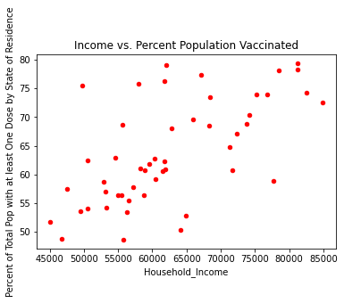

```python
# Create scatterplot to visualize relationship between income and percent of population that has been vaccinated
import matplotlib.pyplot as plt
vaccine_income_df.plot(kind = "scatter", x = 'Household_Income', y = 'Percent of Total Pop with at least One Dose by State of Residence', color = 'red', title = "Income vs. Percent Population Vaccinated")
plt.show()
```

```python
# calculate the correlation between household income and percent of populations vaccinated
variables = ["Household_Income", 'Percent of Total Pop with at least One Dose by State of Residence']
vaccine_income_df[variables].corr()
```

|  | Household_Income | Percent of Total Pop with at least One Dose by State of Residence |
| --- | --- | --- |
| Household_Income | 1.000000 | 0.630108 |
| Percent of Total Pop with at least One Dose by State of Residence | 0.630108 | 1.000000 |

### Household Income Analysis:

The correlation between income and having at least one dose of the vaccine is 0.630108, which is decently high. There is a moderate correlation between these two variables.

# Obtaining State Demographics Data

The state demographics data set contains state-level data regarding education levels, ethinicity and race distributions, employment rates, and other socio-economic factors. Each of these factors can be analyzed individually in relation to vaccine rates in each state.

```python
state_demo_df = pd.read_csv("data/state_demographics.csv")
state_demo_df = state_demo_df.set_index("State")
state_demo_df = state_demo_df.drop(['District of Columbia'], axis = 0)
state_demo_df = state_demo_df.drop(['Population.2010 Population','Employment.Firms.Nonveteran-Owned','Employment.Firms.Veteran-Owned','Employment.Firms.Nonminority-Owned','Employment.Firms.Women-Owned','Employment.Firms.Men-Owned','Employment.Firms.Total','Employment.Nonemployer Establishments','Sales.Retail Sales','Miscellaneous.Manufacturers Shipments','Sales.Accommodation and Food Services Sales','Housing.Households with a Internet','Housing.Households with a computer','Miscellaneous.Language Other than English at Home','Miscellaneous.Living in Same House +1 Years','Housing.Persons per Household','Housing.Households','Housing.Housing Units','Miscellaneous.Foreign Born','Miscellaneous.Veterans'],axis = 1)
state_demo_df
```

| State | Population.Population Percent Change | Population.2014 Population | Age.Percent Under 5 Years | Age.Percent Under 18 Years | Age.Percent 65 and Older | Miscellaneous.Percent Female | Ethnicities.White Alone | Ethnicities.Black Alone | Ethnicities.American Indian and Alaska Native Alone | Ethnicities.Asian Alone | Ethnicities.Native Hawaiian and Other Pacific Islander Alone | Ethnicities.Two or More Races | Ethnicities.Hispanic or Latino | Ethnicities.White Alone, not Hispanic or Latino | Housing.Homeownership Rate | Housing.Median Value of Owner-Occupied Units | Education.High School or Higher | Education.Bachelor's Degree or Higher | Miscellaneous.Percent Under 66 Years With a Disability | Miscellaneous.Percent Under 65 Years Witout Health insurance | Miscellaneous.Mean Travel Time to Work | Income.Median Houseold Income | Income.Per Capita Income | Income.Persons Below Poverty Level | Employment.Firms.Minority-Owned | Population.Population per Square Mile | Miscellaneous.Land Area |
| --- | --- | --- | --- | --- | --- | --- | --- | --- | --- | --- | --- | --- | --- | --- | --- | --- | --- | --- | --- | --- | --- | --- | --- | --- | --- | --- | --- |
| Connecticut | -10.2 | 3605944 | 5.1 | 20.4 | 17.7 | 51.2 | 79.7 | 12.2 | 0.6 | 5.0 | 0.1 | 2.5 | 16.9 | 65.9 | 66.1 | 275400 | 90.6 | 39.3 | 7.4 | 7.0 | 26.6 | 78444 | 44496 | 10.0 | 56113 | 738.1 | 4842.36 |
| Delaware | 8.4 | 989948 | 5.6 | 20.9 | 19.4 | 51.7 | 69.2 | 23.2 | 0.7 | 4.1 | 0.1 | 2.7 | 9.6 | 61.7 | 71.2 | 251100 | 90.0 | 32.0 | 8.7 | 8.1 | 26.3 | 68287 | 35450 | 11.3 | 14440 | 460.8 | 1948.54 |
| Florida | 14.2 | 21538187 | 5.3 | 19.7 | 20.9 | 51.1 | 77.3 | 16.9 | 0.5 | 3.0 | 0.1 | 2.2 | 26.4 | 53.2 | 65.4 | 215300 | 88.2 | 29.9 | 8.6 | 16.3 | 27.8 | 55660 | 31619 | 12.7 | 926112 | 350.6 | 53624.76 |
| Georgia | 9.6 | 10711908 | 6.2 | 23.6 | 14.3 | 51.4 | 60.2 | 32.6 | 0.5 | 4.4 | 0.1 | 2.2 | 9.9 | 52.0 | 63.3 | 176000 | 87.1 | 31.3 | 8.7 | 15.5 | 28.8 | 58700 | 31067 | 13.3 | 371588 | 168.4 | 57513.49 |
| Hawaii | 4.1 | 1455271 | 6.0 | 21.2 | 19.0 | 50.0 | 25.5 | 2.2 | 0.4 | 37.6 | 10.1 | 24.2 | 10.7 | 21.7 | 58.9 | 615300 | 92.0 | 33.0 | 6.4 | 5.0 | 27.5 | 81275 | 35567 | 9.3 | 74208 | 211.8 | 6422.63 |
| Alabama | 2.6 | 5024279 | 6.0 | 22.2 | 17.3 | 51.7 | 69.1 | 26.8 | 0.7 | 1.5 | 0.1 | 1.8 | 4.6 | 65.3 | 68.8 | 142700 | 86.2 | 25.5 | 11.6 | 11.7 | 24.9 | 50536 | 27928 | 15.5 | 92219 | 94.4 | 50645.33 |
| Alaska | 3.0 | 733391 | 7.0 | 24.6 | 12.5 | 47.9 | 65.3 | 3.7 | 15.6 | 6.5 | 1.4 | 7.5 | 7.3 | 60.2 | 64.3 | 270400 | 92.8 | 29.6 | 8.9 | 13.9 | 19.1 | 77640 | 36787 | 10.1 | 13688 | 1.2 | 570640.95 |
| Arizona | 13.9 | 7151502 | 5.9 | 22.5 | 18.0 | 50.3 | 82.6 | 5.2 | 5.3 | 3.7 | 0.3 | 2.9 | 31.7 | 54.1 | 64.4 | 225500 | 87.1 | 29.5 | 8.7 | 13.6 | 25.7 | 58945 | 30694 | 13.5 | 135313 | 56.3 | 113594.08 |
| Arkansas | 3.5 | 3011524 | 6.2 | 23.2 | 17.4 | 50.9 | 79.0 | 15.7 | 1.0 | 1.7 | 0.4 | 2.2 | 7.8 | 72.0 | 65.6 | 127800 | 86.6 | 23.0 | 12.6 | 10.9 | 21.7 | 47597 | 26577 | 16.2 | 35982 | 56.0 | 52035.48 |
| California | 6.1 | 39538223 | 6.0 | 22.5 | 14.8 | 50.3 | 71.9 | 6.5 | 1.6 | 15.5 | 0.5 | 4.0 | 39.4 | 36.5 | 54.8 | 505000 | 83.3 | 33.9 | 6.7 | 8.9 | 29.8 | 75235 | 36955 | 11.8 | 1619857 | 239.1 | 155779.22 |
| Colorado | 14.5 | 5773714 | 5.8 | 21.9 | 14.6 | 49.6 | 86.9 | 4.6 | 1.6 | 3.5 | 0.2 | 3.1 | 21.8 | 67.7 | 65.2 | 343300 | 91.7 | 40.9 | 7.2 | 9.3 | 25.8 | 72331 | 38226 | 9.3 | 85849 | 48.5 | 103641.89 |
| Louisiana | 2.5 | 4657757 | 6.5 | 23.4 | 15.9 | 51.2 | 62.8 | 32.8 | 0.8 | 1.8 | 0.1 | 1.8 | 5.3 | 58.4 | 65.6 | 163100 | 85.2 | 24.1 | 11.1 | 10.5 | 25.7 | 49469 | 27923 | 19.0 | 126100 | 104.9 | 43203.90 |
| Maine | 1.2 | 1362359 | 4.7 | 18.5 | 21.2 | 51.0 | 94.4 | 1.7 | 0.7 | 1.3 | 0.0 | 1.8 | 1.8 | 93.0 | 72.3 | 190400 | 92.6 | 31.8 | 11.7 | 10.1 | 24.2 | 57918 | 32637 | 10.9 | 4339 | 43.1 | 30842.92 |
| Montana | 8.0 | 1084225 | 5.7 | 21.4 | 19.3 | 49.7 | 88.9 | 0.6 | 6.7 | 0.9 | 0.1 | 2.8 | 4.1 | 85.9 | 68.1 | 230600 | 93.6 | 32.0 | 9.2 | 10.2 | 18.3 | 54970 | 31151 | 12.6 | 5578 | 6.8 | 145545.80 |
| Nebraska | 5.9 | 1961504 | 6.8 | 24.6 | 16.2 | 50.0 | 88.1 | 5.2 | 1.5 | 2.7 | 0.1 | 2.3 | 11.4 | 78.2 | 66.1 | 155800 | 91.4 | 31.9 | 7.8 | 9.8 | 18.8 | 61439 | 32302 | 9.9 | 14571 | 23.8 | 76824.17 |
| Nevada | 14.1 | 3104614 | 6.0 | 22.5 | 16.1 | 49.8 | 73.9 | 10.3 | 1.7 | 8.7 | 0.8 | 4.6 | 29.2 | 48.2 | 56.3 | 267900 | 86.7 | 24.7 | 8.6 | 13.4 | 24.6 | 60365 | 31557 | 12.5 | 71864 | 24.6 | 109781.18 |
| New Hampshire | 3.3 | 1377529 | 4.7 | 18.8 | 18.7 | 50.4 | 93.1 | 1.8 | 0.3 | 3.0 | 0.0 | 1.8 | 4.0 | 89.8 | 71.1 | 261700 | 93.1 | 37.0 | 9.0 | 7.6 | 27.5 | 76768 | 40003 | 7.3 | 6111 | 147.0 | 8952.65 |
| Idaho | 14.0 | 1839106 | 6.5 | 25.1 | 16.3 | 49.9 | 93.0 | 0.9 | 1.7 | 1.6 | 0.2 | 2.6 | 12.8 | 81.6 | 70.0 | 212300 | 90.8 | 27.6 | 9.6 | 12.8 | 21.1 | 55785 | 27970 | 11.2 | 10592 | 19.0 | 82643.12 |
| Illinois | -11.2 | 12812508 | 5.9 | 22.2 | 16.1 | 50.9 | 76.8 | 14.6 | 0.6 | 5.9 | 0.1 | 2.1 | 17.5 | 60.8 | 66.1 | 194500 | 89.2 | 34.7 | 7.2 | 8.6 | 29.2 | 65886 | 36038 | 11.5 | 311684 | 231.1 | 55518.93 |
| Indiana | 3.8 | 6785528 | 6.2 | 23.3 | 16.1 | 50.7 | 84.8 | 9.9 | 0.4 | 2.6 | 0.1 | 2.2 | 7.3 | 78.4 | 69.1 | 141700 | 88.8 | 26.5 | 9.7 | 10.3 | 23.8 | 56303 | 29777 | 11.9 | 61252 | 181.0 | 35826.11 |
| Iowa | 3.6 | 3190369 | 6.2 | 23.0 | 17.5 | 50.2 | 90.6 | 4.1 | 0.5 | 2.7 | 0.2 | 2.0 | 6.3 | 85.0 | 71.1 | 147800 | 92.1 | 28.6 | 7.9 | 6.0 | 19.3 | 60523 | 32176 | 11.2 | 14707 | 54.5 | 55857.13 |
| Kansas | 2.1 | 2937880 | 6.4 | 24.0 | 16.3 | 50.2 | 86.3 | 6.1 | 1.2 | 3.2 | 0.1 | 3.1 | 12.2 | 75.4 | 66.3 | 151900 | 91.0 | 33.4 | 9.0 | 10.9 | 19.4 | 59597 | 31814 | 11.4 | 26127 | 34.9 | 81758.72 |
| Kentucky | 3.0 | 4505836 | 6.1 | 22.4 | 16.8 | 50.7 | 87.5 | 8.5 | 0.3 | 1.6 | 0.1 | 2.0 | 3.9 | 84.1 | 67.2 | 141000 | 86.3 | 24.2 | 13.2 | 7.7 | 23.6 | 50589 | 28178 | 16.3 | 27258 | 109.9 | 39486.34 |
| Oklahoma | 5.5 | 3959353 | 6.5 | 24.1 | 16.1 | 50.5 | 74.0 | 7.8 | 9.4 | 2.4 | 0.2 | 6.3 | 11.1 | 65.0 | 65.6 | 136800 | 88.0 | 25.5 | 11.5 | 16.8 | 21.9 | 52919 | 28422 | 15.2 | 64875 | 54.7 | 68594.92 |
| Oregon | 10.1 | 4237256 | 5.4 | 20.5 | 18.2 | 50.4 | 86.7 | 2.2 | 1.8 | 4.9 | 0.5 | 4.0 | 13.4 | 75.1 | 62.4 | 312200 | 90.7 | 33.7 | 9.9 | 8.6 | 23.9 | 62818 | 33763 | 11.4 | 41456 | 39.9 | 95988.01 |
| Maryland | 4.7 | 6177224 | 6.0 | 22.1 | 15.9 | 51.6 | 58.5 | 31.1 | 0.6 | 6.7 | 0.1 | 2.9 | 10.6 | 50.0 | 66.9 | 314800 | 90.2 | 40.2 | 7.5 | 6.9 | 33.2 | 84805 | 42122 | 9.0 | 203394 | 594.8 | 9707.24 |
| Massachusetts | 5.3 | 7029917 | 5.2 | 19.6 | 17.0 | 51.5 | 80.6 | 9.0 | 0.5 | 7.2 | 0.1 | 2.6 | 12.4 | 71.1 | 62.4 | 381600 | 90.8 | 43.7 | 7.8 | 3.5 | 30.2 | 81215 | 43761 | 9.4 | 89967 | 839.4 | 7800.06 |
| Michigan | 1.0 | 10077331 | 5.7 | 21.5 | 17.7 | 50.7 | 79.2 | 14.1 | 0.7 | 3.4 | 0.0 | 2.5 | 5.3 | 74.7 | 71.2 | 154900 | 90.8 | 29.1 | 10.2 | 6.9 | 24.6 | 57144 | 31713 | 13.0 | 158946 | 174.8 | 56538.90 |
| Minnesota | 6.3 | 5706494 | 6.2 | 23.1 | 16.3 | 50.2 | 83.8 | 7.0 | 1.4 | 5.2 | 0.1 | 2.6 | 5.6 | 79.1 | 71.6 | 223900 | 93.1 | 36.1 | 7.3 | 5.8 | 23.7 | 71306 | 37625 | 9.0 | 47302 | 66.6 | 79626.74 |
| Tennessee | 7.6 | 6910840 | 6.0 | 22.1 | 16.7 | 51.2 | 78.4 | 17.1 | 0.5 | 2.0 | 0.1 | 2.0 | 5.7 | 73.5 | 66.3 | 167200 | 87.5 | 27.3 | 11.0 | 12.1 | 25.2 | 53320 | 29859 | 13.9 | 105234 | 153.9 | 41234.90 |
| Texas | 15.3 | 29145505 | 6.9 | 25.5 | 12.9 | 50.3 | 78.7 | 12.9 | 1.0 | 5.2 | 0.1 | 2.1 | 39.7 | 41.2 | 62.0 | 172500 | 83.7 | 29.9 | 7.9 | 20.8 | 26.6 | 61874 | 31277 | 13.6 | 1070392 | 96.3 | 261231.71 |
| Utah | 16.0 | 3271616 | 7.7 | 29.0 | 11.4 | 49.6 | 90.6 | 1.5 | 1.6 | 2.7 | 1.1 | 2.6 | 14.4 | 77.8 | 70.2 | 279100 | 92.3 | 34.0 | 6.8 | 10.8 | 21.9 | 71621 | 29775 | 8.9 | 24423 | 33.6 | 82169.62 |
| Vermont | -10.3 | 643077 | 4.7 | 18.3 | 20.0 | 50.6 | 94.2 | 1.4 | 0.4 | 1.9 | 0.0 | 2.0 | 2.0 | 92.6 | 70.8 | 227700 | 92.7 | 38.0 | 10.6 | 5.6 | 23.3 | 61973 | 34577 | 10.2 | 2354 | 67.9 | 9216.66 |
| Virginia | 6.7 | 8631393 | 5.9 | 21.8 | 15.9 | 50.8 | 69.4 | 19.9 | 0.5 | 6.9 | 0.1 | 3.2 | 9.8 | 61.2 | 66.3 | 273100 | 89.7 | 38.8 | 8.0 | 9.3 | 28.7 | 74222 | 39278 | 9.9 | 185043 | 202.6 | 39490.09 |
| Washington | 13.2 | 7705281 | 6.0 | 21.8 | 15.9 | 49.9 | 78.5 | 4.4 | 1.9 | 9.6 | 0.8 | 4.9 | 13.0 | 67.5 | 63.0 | 339000 | 91.3 | 36.0 | 8.7 | 7.7 | 28.0 | 73775 | 38915 | 9.8 | 92807 | 101.2 | 66455.52 |
| Mississippi | 0.3 | 2961279 | 6.2 | 23.5 | 16.4 | 51.5 | 59.1 | 37.8 | 0.6 | 1.1 | 0.1 | 1.3 | 3.4 | 56.4 | 68.2 | 119000 | 84.5 | 22.0 | 11.9 | 15.4 | 24.8 | 45081 | 24369 | 19.6 | 74824 | 63.2 | 46923.27 |
| Missouri | 2.5 | 6154913 | 6.0 | 22.3 | 17.3 | 50.9 | 82.9 | 11.8 | 0.6 | 2.2 | 0.2 | 2.4 | 4.4 | 79.1 | 66.8 | 157200 | 89.9 | 29.2 | 10.3 | 12.0 | 23.9 | 55461 | 30810 | 12.9 | 61035 | 87.1 | 68741.52 |
| Pennsylvania | 0.8 | 13002700 | 5.5 | 20.6 | 18.7 | 51.0 | 81.6 | 12.0 | 0.4 | 3.8 | 0.1 | 2.1 | 7.8 | 75.7 | 68.9 | 180200 | 90.5 | 31.4 | 9.8 | 7.0 | 27.2 | 61744 | 34352 | 12.0 | 131512 | 283.9 | 44742.70 |
| Rhode Island | 0.6 | 1097379 | 5.1 | 19.3 | 17.7 | 51.3 | 83.6 | 8.5 | 1.1 | 3.7 | 0.2 | 2.9 | 16.3 | 71.4 | 60.8 | 261900 | 88.8 | 34.2 | 9.7 | 4.8 | 25.2 | 67167 | 36121 | 10.8 | 14737 | 1018.1 | 1033.81 |
| South Carolina | 11.3 | 5118425 | 5.7 | 21.6 | 18.2 | 51.6 | 68.6 | 27.0 | 0.5 | 1.8 | 0.1 | 2.0 | 6.0 | 63.7 | 69.4 | 162300 | 87.5 | 28.1 | 10.2 | 13.2 | 25.0 | 53199 | 29426 | 13.8 | 83233 | 153.9 | 30060.70 |
| South Dakota | 8.7 | 886667 | 6.9 | 24.5 | 17.2 | 49.5 | 84.6 | 2.3 | 9.0 | 1.5 | 0.1 | 2.5 | 4.2 | 81.5 | 67.8 | 167100 | 91.7 | 28.8 | 8.1 | 12.2 | 17.2 | 58275 | 30773 | 11.9 | 4101 | 10.7 | 75811.00 |
| New Jersey | 1.0 | 9288994 | 5.8 | 21.8 | 16.6 | 51.1 | 71.9 | 15.1 | 0.6 | 10.0 | 0.1 | 2.3 | 20.9 | 54.6 | 63.9 | 335600 | 89.8 | 39.7 | 6.5 | 9.2 | 32.2 | 82545 | 42745 | 9.2 | 237242 | 1195.5 | 7354.22 |
| New Mexico | 1.8 | 2117522 | 5.8 | 22.7 | 18.0 | 50.5 | 81.9 | 2.6 | 11.0 | 1.8 | 0.2 | 2.6 | 49.3 | 36.8 | 67.7 | 171400 | 85.6 | 27.3 | 10.5 | 12.0 | 22.3 | 49754 | 27230 | 18.2 | 60622 | 17.0 | 121298.15 |
| New York | 0.4 | 20201249 | 5.8 | 20.7 | 16.9 | 51.4 | 69.6 | 17.6 | 1.0 | 9.0 | 0.1 | 2.7 | 19.3 | 55.3 | 53.9 | 313700 | 86.8 | 36.6 | 7.6 | 6.1 | 33.6 | 68486 | 39326 | 13.0 | 709021 | 411.2 | 47126.40 |
| North Carolina | 10.0 | 10439388 | 5.8 | 21.9 | 16.7 | 51.4 | 70.6 | 22.2 | 1.6 | 3.2 | 0.1 | 2.3 | 9.8 | 62.6 | 65.2 | 172500 | 87.8 | 31.3 | 9.4 | 13.4 | 24.8 | 54602 | 30783 | 13.6 | 183380 | 196.1 | 48617.91 |
| North Dakota | 13.3 | 779094 | 7.1 | 23.6 | 15.7 | 48.8 | 86.9 | 3.4 | 5.6 | 1.7 | 0.1 | 2.3 | 4.1 | 83.7 | 62.4 | 193900 | 92.6 | 30.0 | 7.2 | 8.1 | 17.3 | 64894 | 36062 | 10.6 | 3190 | 9.7 | 69000.80 |
| Ohio | 1.3 | 11799448 | 5.9 | 22.1 | 17.5 | 51.0 | 81.7 | 13.1 | 0.3 | 2.5 | 0.1 | 2.4 | 4.0 | 78.4 | 66.1 | 145700 | 90.4 | 28.3 | 10.0 | 7.8 | 23.7 | 56602 | 31552 | 13.1 | 122653 | 282.3 | 40860.69 |
| West Virginia | -13.3 | 1793716 | 5.2 | 20.1 | 20.5 | 50.5 | 93.5 | 3.6 | 0.3 | 0.8 | 0.0 | 1.8 | 1.7 | 92.0 | 73.2 | 119600 | 86.9 | 20.6 | 14.0 | 8.3 | 25.9 | 46711 | 26480 | 16.0 | 5777 | 77.1 | 24038.21 |
| Wisconsin | 2.4 | 5893718 | 5.7 | 21.8 | 17.5 | 50.2 | 87.0 | 6.7 | 1.2 | 3.0 | 0.1 | 2.0 | 7.1 | 80.9 | 67.0 | 180600 | 92.2 | 30.1 | 8.0 | 6.8 | 22.2 | 61747 | 33375 | 10.4 | 40507 | 105.0 | 54157.80 |
| Wyoming | 2.7 | 576851 | 6.0 | 23.1 | 17.1 | 49.1 | 92.5 | 1.3 | 2.7 | 1.1 | 0.1 | 2.2 | 10.1 | 83.7 | 70.4 | 220500 | 93.2 | 27.4 | 8.9 | 14.8 | 17.9 | 64049 | 33366 | 10.1 | 4077 | 5.8 | 97093.14 |

```python
state_demo_df.dtypes
# all dtypes are numerical
```

```
Population.Population Percent Change                            float64
Population.2014 Population                                        int64
Age.Percent Under 5 Years                                       float64
Age.Percent Under 18 Years                                      float64
Age.Percent 65 and Older                                        float64
Miscellaneous.Percent Female                                    float64
Ethnicities.White Alone                                         float64
Ethnicities.Black Alone                                         float64
Ethnicities.American Indian and Alaska Native Alone             float64
Ethnicities.Asian Alone                                         float64
Ethnicities.Native Hawaiian and Other Pacific Islander Alone    float64
Ethnicities.Two or More Races                                   float64
Ethnicities.Hispanic or Latino                                  float64
Ethnicities.White Alone, not Hispanic or Latino                 float64
Housing.Homeownership Rate                                      float64
Housing.Median Value of Owner-Occupied Units                      int64
Education.High School or Higher                                 float64
Education.Bachelor's Degree or Higher                           float64
Miscellaneous.Percent Under 66 Years With a Disability          float64
Miscellaneous.Percent Under 65 Years Witout Health insurance    float64
Miscellaneous.Mean Travel Time to Work                          float64
Income.Median Houseold Income                                     int64
Income.Per Capita Income                                          int64
Income.Persons Below Poverty Level                              float64
Employment.Firms.Minority-Owned                                   int64
Population.Population per Square Mile                           float64
Miscellaneous.Land Area                                         float64
dtype: object
```

```python
# create new data frame containing demographics and vaccine data
vaccine_education_df = state_demo_df.join(vac_state, how = "outer")
vaccine_education_df
```

| State | Population.Population Percent Change | Population.2014 Population | Age.Percent Under 5 Years | Age.Percent Under 18 Years | Age.Percent 65 and Older | Miscellaneous.Percent Female | Ethnicities.White Alone | Ethnicities.Black Alone | Ethnicities.American Indian and Alaska Native Alone | Ethnicities.Asian Alone | Ethnicities.Native Hawaiian and Other Pacific Islander Alone | Ethnicities.Two or More Races | Ethnicities.Hispanic or Latino | Ethnicities.White Alone, not Hispanic or Latino | Housing.Homeownership Rate | Housing.Median Value of Owner-Occupied Units | Education.High School or Higher | Education.Bachelor's Degree or Higher | Miscellaneous.Percent Under 66 Years With a Disability | Miscellaneous.Percent Under 65 Years Witout Health insurance | Miscellaneous.Mean Travel Time to Work | Income.Median Houseold Income | Income.Per Capita Income | Income.Persons Below Poverty Level | Employment.Firms.Minority-Owned | Population.Population per Square Mile | Miscellaneous.Land Area | People with at least One Dose by State of Residence | Percent of Total Pop with at least One Dose by State of Residence | … |
| --- | --- | --- | --- | --- | --- | --- | --- | --- | --- | --- | --- | --- | --- | --- | --- | --- | --- | --- | --- | --- | --- | --- | --- | --- | --- | --- | --- | --- | --- | --- |
| Alabama | 2.6 | 5024279 | 6.0 | 22.2 | 17.3 | 51.7 | 69.1 | 26.8 | 0.7 | 1.5 | 0.1 | 1.8 | 4.6 | 65.3 | 68.8 | 142700 | 86.2 | 25.5 | 11.6 | 11.7 | 24.9 | 50536 | 27928 | 15.5 | 92219 | 94.4 | 50645.33 | 2648588 | 54.0 | … |
| Alaska | 3.0 | 733391 | 7.0 | 24.6 | 12.5 | 47.9 | 65.3 | 3.7 | 15.6 | 6.5 | 1.4 | 7.5 | 7.3 | 60.2 | 64.3 | 270400 | 92.8 | 29.6 | 8.9 | 13.9 | 19.1 | 77640 | 36787 | 10.1 | 13688 | 1.2 | 570640.95 | 431007 | 58.9 | … |
| Arizona | 13.9 | 7151502 | 5.9 | 22.5 | 18.0 | 50.3 | 82.6 | 5.2 | 5.3 | 3.7 | 0.3 | 2.9 | 31.7 | 54.1 | 64.4 | 225500 | 87.1 | 29.5 | 8.7 | 13.6 | 25.7 | 58945 | 30694 | 13.5 | 135313 | 56.3 | 113594.08 | 4426640 | 60.8 | … |
| Arkansas | 3.5 | 3011524 | 6.2 | 23.2 | 17.4 | 50.9 | 79.0 | 15.7 | 1.0 | 1.7 | 0.4 | 2.2 | 7.8 | 72.0 | 65.6 | 127800 | 86.6 | 23.0 | 12.6 | 10.9 | 21.7 | 47597 | 26577 | 16.2 | 35982 | 56.0 | 52035.48 | 1735828 | 57.5 | … |
| California | 6.1 | 39538223 | 6.0 | 22.5 | 14.8 | 50.3 | 71.9 | 6.5 | 1.6 | 15.5 | 0.5 | 4.0 | 39.4 | 36.5 | 54.8 | 505000 | 83.3 | 33.9 | 6.7 | 8.9 | 29.8 | 75235 | 36955 | 11.8 | 1619857 | 239.1 | 155779.22 | 29182133 | 73.9 | … |
| Colorado | 14.5 | 5773714 | 5.8 | 21.9 | 14.6 | 49.6 | 86.9 | 4.6 | 1.6 | 3.5 | 0.2 | 3.1 | 21.8 | 67.7 | 65.2 | 343300 | 91.7 | 40.9 | 7.2 | 9.3 | 25.8 | 72331 | 38226 | 9.3 | 85849 | 48.5 | 103641.89 | 3864323 | 67.1 | … |
| Connecticut | -10.2 | 3605944 | 5.1 | 20.4 | 17.7 | 51.2 | 79.7 | 12.2 | 0.6 | 5.0 | 0.1 | 2.5 | 16.9 | 65.9 | 66.1 | 275400 | 90.6 | 39.3 | 7.4 | 7.0 | 26.6 | 78444 | 44496 | 10.0 | 56113 | 738.1 | 4842.36 | 2789281 | 78.2 | … |
| Delaware | 8.4 | 989948 | 5.6 | 20.9 | 19.4 | 51.7 | 69.2 | 23.2 | 0.7 | 4.1 | 0.1 | 2.7 | 9.6 | 61.7 | 71.2 | 251100 | 90.0 | 32.0 | 8.7 | 8.1 | 26.3 | 68287 | 35450 | 11.3 | 14440 | 460.8 | 1948.54 | 666545 | 68.5 | … |
| Florida | 14.2 | 21538187 | 5.3 | 19.7 | 20.9 | 51.1 | 77.3 | 16.9 | 0.5 | 3.0 | 0.1 | 2.2 | 26.4 | 53.2 | 65.4 | 215300 | 88.2 | 29.9 | 8.6 | 16.3 | 27.8 | 55660 | 31619 | 12.7 | 926112 | 350.6 | 53624.76 | 14736801 | 68.6 | … |
| Georgia | 9.6 | 10711908 | 6.2 | 23.6 | 14.3 | 51.4 | 60.2 | 32.6 | 0.5 | 4.4 | 0.1 | 2.2 | 9.9 | 52.0 | 63.3 | 176000 | 87.1 | 31.3 | 8.7 | 15.5 | 28.8 | 58700 | 31067 | 13.3 | 371588 | 168.4 | 57513.49 | 5988571 | 56.4 | … |
| Hawaii | 4.1 | 1455271 | 6.0 | 21.2 | 19.0 | 50.0 | 25.5 | 2.2 | 0.4 | 37.6 | 10.1 | 24.2 | 10.7 | 21.7 | 58.9 | 615300 | 92.0 | 33.0 | 6.4 | 5.0 | 27.5 | 81275 | 35567 | 9.3 | 74208 | 211.8 | 6422.63 | 1108150 | 78.3 | … |
| Idaho | 14.0 | 1839106 | 6.5 | 25.1 | 16.3 | 49.9 | 93.0 | 0.9 | 1.7 | 1.6 | 0.2 | 2.6 | 12.8 | 81.6 | 70.0 | 212300 | 90.8 | 27.6 | 9.6 | 12.8 | 21.1 | 55785 | 27970 | 11.2 | 10592 | 19.0 | 82643.12 | 867779 | 48.6 | … |
| Illinois | -11.2 | 12812508 | 5.9 | 22.2 | 16.1 | 50.9 | 76.8 | 14.6 | 0.6 | 5.9 | 0.1 | 2.1 | 17.5 | 60.8 | 66.1 | 194500 | 89.2 | 34.7 | 7.2 | 8.6 | 29.2 | 65886 | 36038 | 11.5 | 311684 | 231.1 | 55518.93 | 8814692 | 69.6 | … |
| Indiana | 3.8 | 6785528 | 6.2 | 23.3 | 16.1 | 50.7 | 84.8 | 9.9 | 0.4 | 2.6 | 0.1 | 2.2 | 7.3 | 78.4 | 69.1 | 141700 | 88.8 | 26.5 | 9.7 | 10.3 | 23.8 | 56303 | 29777 | 11.9 | 61252 | 181.0 | 35826.11 | 3594059 | 53.4 | … |
| Iowa | 3.6 | 3190369 | 6.2 | 23.0 | 17.5 | 50.2 | 90.6 | 4.1 | 0.5 | 2.7 | 0.2 | 2.0 | 6.3 | 85.0 | 71.1 | 147800 | 92.1 | 28.6 | 7.9 | 6.0 | 19.3 | 60523 | 32176 | 11.2 | 14707 | 54.5 | 55857.13 | 1868635 | 59.2 | … |
| Kansas | 2.1 | 2937880 | 6.4 | 24.0 | 16.3 | 50.2 | 86.3 | 6.1 | 1.2 | 3.2 | 0.1 | 3.1 | 12.2 | 75.4 | 66.3 | 151900 | 91.0 | 33.4 | 9.0 | 10.9 | 19.4 | 59597 | 31814 | 11.4 | 26127 | 34.9 | 81758.72 | 1799279 | 61.8 | … |
| Kentucky | 3.0 | 4505836 | 6.1 | 22.4 | 16.8 | 50.7 | 87.5 | 8.5 | 0.3 | 1.6 | 0.1 | 2.0 | 3.9 | 84.1 | 67.2 | 141000 | 86.3 | 24.2 | 13.2 | 7.7 | 23.6 | 50589 | 28178 | 16.3 | 27258 | 109.9 | 39486.34 | 2788558 | 62.4 | … |
| Louisiana | 2.5 | 4657757 | 6.5 | 23.4 | 15.9 | 51.2 | 62.8 | 32.8 | 0.8 | 1.8 | 0.1 | 1.8 | 5.3 | 58.4 | 65.6 | 163100 | 85.2 | 24.1 | 11.1 | 10.5 | 25.7 | 49469 | 27923 | 19.0 | 126100 | 104.9 | 43203.90 | 2485608 | 53.5 | … |
| Maine | 1.2 | 1362359 | 4.7 | 18.5 | 21.2 | 51.0 | 94.4 | 1.7 | 0.7 | 1.3 | 0.0 | 1.8 | 1.8 | 93.0 | 72.3 | 190400 | 92.6 | 31.8 | 11.7 | 10.1 | 24.2 | 57918 | 32637 | 10.9 | 4339 | 43.1 | 30842.92 | 1019103 | 75.8 | … |
| Maryland | 4.7 | 6177224 | 6.0 | 22.1 | 15.9 | 51.6 | 58.5 | 31.1 | 0.6 | 6.7 | 0.1 | 2.9 | 10.6 | 50.0 | 66.9 | 314800 | 90.2 | 40.2 | 7.5 | 6.9 | 33.2 | 84805 | 42122 | 9.0 | 203394 | 594.8 | 9707.24 | 4380511 | 72.5 | … |
| Massachusetts | 5.3 | 7029917 | 5.2 | 19.6 | 17.0 | 51.5 | 80.6 | 9.0 | 0.5 | 7.2 | 0.1 | 2.6 | 12.4 | 71.1 | 62.4 | 381600 | 90.8 | 43.7 | 7.8 | 3.5 | 30.2 | 81215 | 43761 | 9.4 | 89967 | 839.4 | 7800.06 | 5471378 | 79.4 | … |
| Michigan | 1.0 | 10077331 | 5.7 | 21.5 | 17.7 | 50.7 | 79.2 | 14.1 | 0.7 | 3.4 | 0.0 | 2.5 | 5.3 | 74.7 | 71.2 | 154900 | 90.8 | 29.1 | 10.2 | 6.9 | 24.6 | 57144 | 31713 | 13.0 | 158946 | 174.8 | 56538.90 | 5765073 | 57.7 | … |
| Minnesota | 6.3 | 5706494 | 6.2 | 23.1 | 16.3 | 50.2 | 83.8 | 7.0 | 1.4 | 5.2 | 0.1 | 2.6 | 5.6 | 79.1 | 71.6 | 223900 | 93.1 | 36.1 | 7.3 | 5.8 | 23.7 | 71306 | 37625 | 9.0 | 47302 | 66.6 | 79626.74 | 3650845 | 64.7 | … |
| Mississippi | 0.3 | 2961279 | 6.2 | 23.5 | 16.4 | 51.5 | 59.1 | 37.8 | 0.6 | 1.1 | 0.1 | 1.3 | 3.4 | 56.4 | 68.2 | 119000 | 84.5 | 22.0 | 11.9 | 15.4 | 24.8 | 45081 | 24369 | 19.6 | 74824 | 63.2 | 46923.27 | 1538491 | 51.7 | … |
| Missouri | 2.5 | 6154913 | 6.0 | 22.3 | 17.3 | 50.9 | 82.9 | 11.8 | 0.6 | 2.2 | 0.2 | 2.4 | 4.4 | 79.1 | 66.8 | 157200 | 89.9 | 29.2 | 10.3 | 12.0 | 23.9 | 55461 | 30810 | 12.9 | 61035 | 87.1 | 68741.52 | 3458360 | 56.3 | … |
| Montana | 8.0 | 1084225 | 5.7 | 21.4 | 19.3 | 49.7 | 88.9 | 0.6 | 6.7 | 0.9 | 0.1 | 2.8 | 4.1 | 85.9 | 68.1 | 230600 | 93.6 | 32.0 | 9.2 | 10.2 | 18.3 | 54970 | 31151 | 12.6 | 5578 | 6.8 | 145545.80 | 601464 | 56.3 | … |
| Nebraska | 5.9 | 1961504 | 6.8 | 24.6 | 16.2 | 50.0 | 88.1 | 5.2 | 1.5 | 2.7 | 0.1 | 2.3 | 11.4 | 78.2 | 66.1 | 155800 | 91.4 | 31.9 | 7.8 | 9.8 | 18.8 | 61439 | 32302 | 9.9 | 14571 | 23.8 | 76824.17 | 1172411 | 60.6 | … |
| Nevada | 14.1 | 3104614 | 6.0 | 22.5 | 16.1 | 49.8 | 73.9 | 10.3 | 1.7 | 8.7 | 0.8 | 4.6 | 29.2 | 48.2 | 56.3 | 267900 | 86.7 | 24.7 | 8.6 | 13.4 | 24.6 | 60365 | 31557 | 12.5 | 71864 | 24.6 | 109781.18 | 1931031 | 62.7 | … |
| New Hampshire | 3.3 | 1377529 | 4.7 | 18.8 | 18.7 | 50.4 | 93.1 | 1.8 | 0.3 | 3.0 | 0.0 | 1.8 | 4.0 | 89.8 | 71.1 | 261700 | 93.1 | 37.0 | 9.0 | 7.6 | 27.5 | 76768 | 40003 | 7.3 | 6111 | 147.0 | 8952.65 | 1004338 | 73.9 | … |
| New Jersey | 1.0 | 9288994 | 5.8 | 21.8 | 16.6 | 51.1 | 71.9 | 15.1 | 0.6 | 10.0 | 0.1 | 2.3 | 20.9 | 54.6 | 63.9 | 335600 | 89.8 | 39.7 | 6.5 | 9.2 | 32.2 | 82545 | 42745 | 9.2 | 237242 | 1195.5 | 7354.22 | 6603866 | 74.3 | … |
| New Mexico | 1.8 | 2117522 | 5.8 | 22.7 | 18.0 | 50.5 | 81.9 | 2.6 | 11.0 | 1.8 | 0.2 | 2.6 | 49.3 | 36.8 | 67.7 | 171400 | 85.6 | 27.3 | 10.5 | 12.0 | 22.3 | 49754 | 27230 | 18.2 | 60622 | 17.0 | 121298.15 | 1584040 | 75.5 | … |
| New York | 0.4 | 20201249 | 5.8 | 20.7 | 16.9 | 51.4 | 69.6 | 17.6 | 1.0 | 9.0 | 0.1 | 2.7 | 19.3 | 55.3 | 53.9 | 313700 | 86.8 | 36.6 | 7.6 | 6.1 | 33.6 | 68486 | 39326 | 13.0 | 709021 | 411.2 | 47126.40 | 14299323 | 73.5 | … |
| North Carolina | 10.0 | 10439388 | 5.8 | 21.9 | 16.7 | 51.4 | 70.6 | 22.2 | 1.6 | 3.2 | 0.1 | 2.3 | 9.8 | 62.6 | 65.2 | 172500 | 87.8 | 31.3 | 9.4 | 13.4 | 24.8 | 54602 | 30783 | 13.6 | 183380 | 196.1 | 48617.91 | 6594225 | 62.9 | … |
| North Dakota | 13.3 | 779094 | 7.1 | 23.6 | 15.7 | 48.8 | 86.9 | 3.4 | 5.6 | 1.7 | 0.1 | 2.3 | 4.1 | 83.7 | 62.4 | 193900 | 92.6 | 30.0 | 7.2 | 8.1 | 17.3 | 64894 | 36062 | 10.6 | 3190 | 9.7 | 69000.80 | 402197 | 52.8 | … |
| Ohio | 1.3 | 11799448 | 5.9 | 22.1 | 17.5 | 51.0 | 81.7 | 13.1 | 0.3 | 2.5 | 0.1 | 2.4 | 4.0 | 78.4 | 66.1 | 145700 | 90.4 | 28.3 | 10.0 | 7.8 | 23.7 | 56602 | 31552 | 13.1 | 122653 | 282.3 | 40860.69 | 6484054 | 55.5 | … |
| Oklahoma | 5.5 | 3959353 | 6.5 | 24.1 | 16.1 | 50.5 | 74.0 | 7.8 | 9.4 | 2.4 | 0.2 | 6.3 | 11.1 | 65.0 | 65.6 | 136800 | 88.0 | 25.5 | 11.5 | 16.8 | 21.9 | 52919 | 28422 | 15.2 | 64875 | 54.7 | 68594.92 | 2323628 | 58.7 | … |
| Oregon | 10.1 | 4237256 | 5.4 | 20.5 | 18.2 | 50.4 | 86.7 | 2.2 | 1.8 | 4.9 | 0.5 | 4.0 | 13.4 | 75.1 | 62.4 | 312200 | 90.7 | 33.7 | 9.9 | 8.6 | 23.9 | 62818 | 33763 | 11.4 | 41456 | 39.9 | 95988.01 | 2866145 | 68.0 | … |
| Pennsylvania | 0.8 | 13002700 | 5.5 | 20.6 | 18.7 | 51.0 | 81.6 | 12.0 | 0.4 | 3.8 | 0.1 | 2.1 | 7.8 | 75.7 | 68.9 | 180200 | 90.5 | 31.4 | 9.8 | 7.0 | 27.2 | 61744 | 34352 | 12.0 | 131512 | 283.9 | 44742.70 | 9763204 | 76.3 | … |
| Rhode Island | 0.6 | 1097379 | 5.1 | 19.3 | 17.7 | 51.3 | 83.6 | 8.5 | 1.1 | 3.7 | 0.2 | 2.9 | 16.3 | 71.4 | 60.8 | 261900 | 88.8 | 34.2 | 9.7 | 4.8 | 25.2 | 67167 | 36121 | 10.8 | 14737 | 1018.1 | 1033.81 | 819423 | 77.4 | … |
| South Carolina | 11.3 | 5118425 | 5.7 | 21.6 | 18.2 | 51.6 | 68.6 | 27.0 | 0.5 | 1.8 | 0.1 | 2.0 | 6.0 | 63.7 | 69.4 | 162300 | 87.5 | 28.1 | 10.2 | 13.2 | 25.0 | 53199 | 29426 | 13.8 | 83233 | 153.9 | 30060.70 | 2932430 | 57.0 | … |
| South Dakota | 8.7 | 886667 | 6.9 | 24.5 | 17.2 | 49.5 | 84.6 | 2.3 | 9.0 | 1.5 | 0.1 | 2.5 | 4.2 | 81.5 | 67.8 | 167100 | 91.7 | 28.8 | 8.1 | 12.2 | 17.2 | 58275 | 30773 | 11.9 | 4101 | 10.7 | 75811.00 | 540479 | 61.1 | … |
| Tennessee | 7.6 | 6910840 | 6.0 | 22.1 | 16.7 | 51.2 | 78.4 | 17.1 | 0.5 | 2.0 | 0.1 | 2.0 | 5.7 | 73.5 | 66.3 | 167200 | 87.5 | 27.3 | 11.0 | 12.1 | 25.2 | 53320 | 29859 | 13.9 | 105234 | 153.9 | 41234.90 | 3698169 | 54.2 | … |
| Texas | 15.3 | 29145505 | 6.9 | 25.5 | 12.9 | 50.3 | 78.7 | 12.9 | 1.0 | 5.2 | 0.1 | 2.1 | 39.7 | 41.2 | 62.0 | 172500 | 83.7 | 29.9 | 7.9 | 20.8 | 26.6 | 61874 | 31277 | 13.6 | 1070392 | 96.3 | 261231.71 | 17669171 | 60.9 | … |
| Utah | 16.0 | 3271616 | 7.7 | 29.0 | 11.4 | 49.6 | 90.6 | 1.5 | 1.6 | 2.7 | 1.1 | 2.6 | 14.4 | 77.8 | 70.2 | 279100 | 92.3 | 34.0 | 6.8 | 10.8 | 21.9 | 71621 | 29775 | 8.9 | 24423 | 33.6 | 82169.62 | 1945336 | 60.7 | … |
| Vermont | -10.3 | 643077 | 4.7 | 18.3 | 20.0 | 50.6 | 94.2 | 1.4 | 0.4 | 1.9 | 0.0 | 2.0 | 2.0 | 92.6 | 70.8 | 227700 | 92.7 | 38.0 | 10.6 | 5.6 | 23.3 | 61973 | 34577 | 10.2 | 2354 | 67.9 | 9216.66 | 493473 | 79.1 | … |
| Virginia | 6.7 | 8631393 | 5.9 | 21.8 | 15.9 | 50.8 | 69.4 | 19.9 | 0.5 | 6.9 | 0.1 | 3.2 | 9.8 | 61.2 | 66.3 | 273100 | 89.7 | 38.8 | 8.0 | 9.3 | 28.7 | 74222 | 39278 | 9.9 | 185043 | 202.6 | 39490.09 | 6009377 | 70.4 | … |
| Washington | 13.2 | 7705281 | 6.0 | 21.8 | 15.9 | 49.9 | 78.5 | 4.4 | 1.9 | 9.6 | 0.8 | 4.9 | 13.0 | 67.5 | 63.0 | 339000 | 91.3 | 36.0 | 8.7 | 7.7 | 28.0 | 73775 | 38915 | 9.8 | 92807 | 101.2 | 66455.52 | 5244471 | 68.9 | … |
| West Virginia | -13.3 | 1793716 | 5.2 | 20.1 | 20.5 | 50.5 | 93.5 | 3.6 | 0.3 | 0.8 | 0.0 | 1.8 | 1.7 | 92.0 | 73.2 | 119600 | 86.9 | 20.6 | 14.0 | 8.3 | 25.9 | 46711 | 26480 | 16.0 | 5777 | 77.1 | 24038.21 | 874709 | 48.8 | … |
| Wisconsin | 2.4 | 5893718 | 5.7 | 21.8 | 17.5 | 50.2 | 87.0 | 6.7 | 1.2 | 3.0 | 0.1 | 2.0 | 7.1 | 80.9 | 67.0 | 180600 | 92.2 | 30.1 | 8.0 | 6.8 | 22.2 | 61747 | 33375 | 10.4 | 40507 | 105.0 | 54157.80 | 3625725 | 62.3 | … |
| Wyoming | 2.7 | 576851 | 6.0 | 23.1 | 17.1 | 49.1 | 92.5 | 1.3 | 2.7 | 1.1 | 0.1 | 2.2 | 10.1 | 83.7 | 70.4 | 220500 | 93.2 | 27.4 | 8.9 | 14.8 | 17.9 | 64049 | 33366 | 10.1 | 4077 | 5.8 | 97093.14 | 291149 | 50.3 | … |

```python
vaccine_education_df
# all dtypes are numerical
```

| State | Population.Population Percent Change | Population.2014 Population | Age.Percent Under 5 Years | Age.Percent Under 18 Years | Age.Percent 65 and Older | Miscellaneous.Percent Female | Ethnicities.White Alone | Ethnicities.Black Alone | Ethnicities.American Indian and Alaska Native Alone | Ethnicities.Asian Alone | Ethnicities.Native Hawaiian and Other Pacific Islander Alone | Ethnicities.Two or More Races | Ethnicities.Hispanic or Latino | Ethnicities.White Alone, not Hispanic or Latino | Housing.Homeownership Rate | Housing.Median Value of Owner-Occupied Units | Education.High School or Higher | Education.Bachelor's Degree or Higher | Miscellaneous.Percent Under 66 Years With a Disability | Miscellaneous.Percent Under 65 Years Witout Health insurance | Miscellaneous.Mean Travel Time to Work | Income.Median Houseold Income | Income.Per Capita Income | Income.Persons Below Poverty Level | Employment.Firms.Minority-Owned | Population.Population per Square Mile | Miscellaneous.Land Area | People with at least One Dose by State of Residence | Percent of Total Pop with at least One Dose by State of Residence | … |
| --- | --- | --- | --- | --- | --- | --- | --- | --- | --- | --- | --- | --- | --- | --- | --- | --- | --- | --- | --- | --- | --- | --- | --- | --- | --- | --- | --- | --- | --- | --- |
| Alabama | 2.6 | 5024279 | 6.0 | 22.2 | 17.3 | 51.7 | 69.1 | 26.8 | 0.7 | 1.5 | 0.1 | 1.8 | 4.6 | 65.3 | 68.8 | 142700 | 86.2 | 25.5 | 11.6 | 11.7 | 24.9 | 50536 | 27928 | 15.5 | 92219 | 94.4 | 50645.33 | 2648588 | 54.0 | … |
| Alaska | 3.0 | 733391 | 7.0 | 24.6 | 12.5 | 47.9 | 65.3 | 3.7 | 15.6 | 6.5 | 1.4 | 7.5 | 7.3 | 60.2 | 64.3 | 270400 | 92.8 | 29.6 | 8.9 | 13.9 | 19.1 | 77640 | 36787 | 10.1 | 13688 | 1.2 | 570640.95 | 431007 | 58.9 | … |
| Arizona | 13.9 | 7151502 | 5.9 | 22.5 | 18.0 | 50.3 | 82.6 | 5.2 | 5.3 | 3.7 | 0.3 | 2.9 | 31.7 | 54.1 | 64.4 | 225500 | 87.1 | 29.5 | 8.7 | 13.6 | 25.7 | 58945 | 30694 | 13.5 | 135313 | 56.3 | 113594.08 | 4426640 | 60.8 | … |
| Arkansas | 3.5 | 3011524 | 6.2 | 23.2 | 17.4 | 50.9 | 79.0 | 15.7 | 1.0 | 1.7 | 0.4 | 2.2 | 7.8 | 72.0 | 65.6 | 127800 | 86.6 | 23.0 | 12.6 | 10.9 | 21.7 | 47597 | 26577 | 16.2 | 35982 | 56.0 | 52035.48 | 1735828 | 57.5 | … |
| California | 6.1 | 39538223 | 6.0 | 22.5 | 14.8 | 50.3 | 71.9 | 6.5 | 1.6 | 15.5 | 0.5 | 4.0 | 39.4 | 36.5 | 54.8 | 505000 | 83.3 | 33.9 | 6.7 | 8.9 | 29.8 | 75235 | 36955 | 11.8 | 1619857 | 239.1 | 155779.22 | 29182133 | 73.9 | … |
| Colorado | 14.5 | 5773714 | 5.8 | 21.9 | 14.6 | 49.6 | 86.9 | 4.6 | 1.6 | 3.5 | 0.2 | 3.1 | 21.8 | 67.7 | 65.2 | 343300 | 91.7 | 40.9 | 7.2 | 9.3 | 25.8 | 72331 | 38226 | 9.3 | 85849 | 48.5 | 103641.89 | 3864323 | 67.1 | … |
| Connecticut | -10.2 | 3605944 | 5.1 | 20.4 | 17.7 | 51.2 | 79.7 | 12.2 | 0.6 | 5.0 | 0.1 | 2.5 | 16.9 | 65.9 | 66.1 | 275400 | 90.6 | 39.3 | 7.4 | 7.0 | 26.6 | 78444 | 44496 | 10.0 | 56113 | 738.1 | 4842.36 | 2789281 | 78.2 | … |
| Delaware | 8.4 | 989948 | 5.6 | 20.9 | 19.4 | 51.7 | 69.2 | 23.2 | 0.7 | 4.1 | 0.1 | 2.7 | 9.6 | 61.7 | 71.2 | 251100 | 90.0 | 32.0 | 8.7 | 8.1 | 26.3 | 68287 | 35450 | 11.3 | 14440 | 460.8 | 1948.54 | 666545 | 68.5 | … |
| Florida | 14.2 | 21538187 | 5.3 | 19.7 | 20.9 | 51.1 | 77.3 | 16.9 | 0.5 | 3.0 | 0.1 | 2.2 | 26.4 | 53.2 | 65.4 | 215300 | 88.2 | 29.9 | 8.6 | 16.3 | 27.8 | 55660 | 31619 | 12.7 | 926112 | 350.6 | 53624.76 | 14736801 | 68.6 | … |
| Georgia | 9.6 | 10711908 | 6.2 | 23.6 | 14.3 | 51.4 | 60.2 | 32.6 | 0.5 | 4.4 | 0.1 | 2.2 | 9.9 | 52.0 | 63.3 | 176000 | 87.1 | 31.3 | 8.7 | 15.5 | 28.8 | 58700 | 31067 | 13.3 | 371588 | 168.4 | 57513.49 | 5988571 | 56.4 | … |
| Hawaii | 4.1 | 1455271 | 6.0 | 21.2 | 19.0 | 50.0 | 25.5 | 2.2 | 0.4 | 37.6 | 10.1 | 24.2 | 10.7 | 21.7 | 58.9 | 615300 | 92.0 | 33.0 | 6.4 | 5.0 | 27.5 | 81275 | 35567 | 9.3 | 74208 | 211.8 | 6422.63 | 1108150 | 78.3 | … |
| Idaho | 14.0 | 1839106 | 6.5 | 25.1 | 16.3 | 49.9 | 93.0 | 0.9 | 1.7 | 1.6 | 0.2 | 2.6 | 12.8 | 81.6 | 70.0 | 212300 | 90.8 | 27.6 | 9.6 | 12.8 | 21.1 | 55785 | 27970 | 11.2 | 10592 | 19.0 | 82643.12 | 867779 | 48.6 | … |
| Illinois | -11.2 | 12812508 | 5.9 | 22.2 | 16.1 | 50.9 | 76.8 | 14.6 | 0.6 | 5.9 | 0.1 | 2.1 | 17.5 | 60.8 | 66.1 | 194500 | 89.2 | 34.7 | 7.2 | 8.6 | 29.2 | 65886 | 36038 | 11.5 | 311684 | 231.1 | 55518.93 | 8814692 | 69.6 | … |
| Indiana | 3.8 | 6785528 | 6.2 | 23.3 | 16.1 | 50.7 | 84.8 | 9.9 | 0.4 | 2.6 | 0.1 | 2.2 | 7.3 | 78.4 | 69.1 | 141700 | 88.8 | 26.5 | 9.7 | 10.3 | 23.8 | 56303 | 29777 | 11.9 | 61252 | 181.0 | 35826.11 | 3594059 | 53.4 | … |
| Iowa | 3.6 | 3190369 | 6.2 | 23.0 | 17.5 | 50.2 | 90.6 | 4.1 | 0.5 | 2.7 | 0.2 | 2.0 | 6.3 | 85.0 | 71.1 | 147800 | 92.1 | 28.6 | 7.9 | 6.0 | 19.3 | 60523 | 32176 | 11.2 | 14707 | 54.5 | 55857.13 | 1868635 | 59.2 | … |
| Kansas | 2.1 | 2937880 | 6.4 | 24.0 | 16.3 | 50.2 | 86.3 | 6.1 | 1.2 | 3.2 | 0.1 | 3.1 | 12.2 | 75.4 | 66.3 | 151900 | 91.0 | 33.4 | 9.0 | 10.9 | 19.4 | 59597 | 31814 | 11.4 | 26127 | 34.9 | 81758.72 | 1799279 | 61.8 | … |
| Kentucky | 3.0 | 4505836 | 6.1 | 22.4 | 16.8 | 50.7 | 87.5 | 8.5 | 0.3 | 1.6 | 0.1 | 2.0 | 3.9 | 84.1 | 67.2 | 141000 | 86.3 | 24.2 | 13.2 | 7.7 | 23.6 | 50589 | 28178 | 16.3 | 27258 | 109.9 | 39486.34 | 2788558 | 62.4 | … |
| Louisiana | 2.5 | 4657757 | 6.5 | 23.4 | 15.9 | 51.2 | 62.8 | 32.8 | 0.8 | 1.8 | 0.1 | 1.8 | 5.3 | 58.4 | 65.6 | 163100 | 85.2 | 24.1 | 11.1 | 10.5 | 25.7 | 49469 | 27923 | 19.0 | 126100 | 104.9 | 43203.90 | 2485608 | 53.5 | … |
| Maine | 1.2 | 1362359 | 4.7 | 18.5 | 21.2 | 51.0 | 94.4 | 1.7 | 0.7 | 1.3 | 0.0 | 1.8 | 1.8 | 93.0 | 72.3 | 190400 | 92.6 | 31.8 | 11.7 | 10.1 | 24.2 | 57918 | 32637 | 10.9 | 4339 | 43.1 | 30842.92 | 1019103 | 75.8 | … |
| Maryland | 4.7 | 6177224 | 6.0 | 22.1 | 15.9 | 51.6 | 58.5 | 31.1 | 0.6 | 6.7 | 0.1 | 2.9 | 10.6 | 50.0 | 66.9 | 314800 | 90.2 | 40.2 | 7.5 | 6.9 | 33.2 | 84805 | 42122 | 9.0 | 203394 | 594.8 | 9707.24 | 4380511 | 72.5 | … |
| Massachusetts | 5.3 | 7029917 | 5.2 | 19.6 | 17.0 | 51.5 | 80.6 | 9.0 | 0.5 | 7.2 | 0.1 | 2.6 | 12.4 | 71.1 | 62.4 | 381600 | 90.8 | 43.7 | 7.8 | 3.5 | 30.2 | 81215 | 43761 | 9.4 | 89967 | 839.4 | 7800.06 | 5471378 | 79.4 | … |
| Michigan | 1.0 | 10077331 | 5.7 | 21.5 | 17.7 | 50.7 | 79.2 | 14.1 | 0.7 | 3.4 | 0.0 | 2.5 | 5.3 | 74.7 | 71.2 | 154900 | 90.8 | 29.1 | 10.2 | 6.9 | 24.6 | 57144 | 31713 | 13.0 | 158946 | 174.8 | 56538.90 | 5765073 | 57.7 | … |
| Minnesota | 6.3 | 5706494 | 6.2 | 23.1 | 16.3 | 50.2 | 83.8 | 7.0 | 1.4 | 5.2 | 0.1 | 2.6 | 5.6 | 79.1 | 71.6 | 223900 | 93.1 | 36.1 | 7.3 | 5.8 | 23.7 | 71306 | 37625 | 9.0 | 47302 | 66.6 | 79626.74 | 3650845 | 64.7 | … |
| Mississippi | 0.3 | 2961279 | 6.2 | 23.5 | 16.4 | 51.5 | 59.1 | 37.8 | 0.6 | 1.1 | 0.1 | 1.3 | 3.4 | 56.4 | 68.2 | 119000 | 84.5 | 22.0 | 11.9 | 15.4 | 24.8 | 45081 | 24369 | 19.6 | 74824 | 63.2 | 46923.27 | 1538491 | 51.7 | … |
| Missouri | 2.5 | 6154913 | 6.0 | 22.3 | 17.3 | 50.9 | 82.9 | 11.8 | 0.6 | 2.2 | 0.2 | 2.4 | 4.4 | 79.1 | 66.8 | 157200 | 89.9 | 29.2 | 10.3 | 12.0 | 23.9 | 55461 | 30810 | 12.9 | 61035 | 87.1 | 68741.52 | 3458360 | 56.3 | … |
| Montana | 8.0 | 1084225 | 5.7 | 21.4 | 19.3 | 49.7 | 88.9 | 0.6 | 6.7 | 0.9 | 0.1 | 2.8 | 4.1 | 85.9 | 68.1 | 230600 | 93.6 | 32.0 | 9.2 | 10.2 | 18.3 | 54970 | 31151 | 12.6 | 5578 | 6.8 | 145545.80 | 601464 | 56.3 | … |
| Nebraska | 5.9 | 1961504 | 6.8 | 24.6 | 16.2 | 50.0 | 88.1 | 5.2 | 1.5 | 2.7 | 0.1 | 2.3 | 11.4 | 78.2 | 66.1 | 155800 | 91.4 | 31.9 | 7.8 | 9.8 | 18.8 | 61439 | 32302 | 9.9 | 14571 | 23.8 | 76824.17 | 1172411 | 60.6 | … |
| Nevada | 14.1 | 3104614 | 6.0 | 22.5 | 16.1 | 49.8 | 73.9 | 10.3 | 1.7 | 8.7 | 0.8 | 4.6 | 29.2 | 48.2 | 56.3 | 267900 | 86.7 | 24.7 | 8.6 | 13.4 | 24.6 | 60365 | 31557 | 12.5 | 71864 | 24.6 | 109781.18 | 1931031 | 62.7 | … |
| New Hampshire | 3.3 | 1377529 | 4.7 | 18.8 | 18.7 | 50.4 | 93.1 | 1.8 | 0.3 | 3.0 | 0.0 | 1.8 | 4.0 | 89.8 | 71.1 | 261700 | 93.1 | 37.0 | 9.0 | 7.6 | 27.5 | 76768 | 40003 | 7.3 | 6111 | 147.0 | 8952.65 | 1004338 | 73.9 | … |
| New Jersey | 1.0 | 9288994 | 5.8 | 21.8 | 16.6 | 51.1 | 71.9 | 15.1 | 0.6 | 10.0 | 0.1 | 2.3 | 20.9 | 54.6 | 63.9 | 335600 | 89.8 | 39.7 | 6.5 | 9.2 | 32.2 | 82545 | 42745 | 9.2 | 237242 | 1195.5 | 7354.22 | 6603866 | 74.3 | … |
| New Mexico | 1.8 | 2117522 | 5.8 | 22.7 | 18.0 | 50.5 | 81.9 | 2.6 | 11.0 | 1.8 | 0.2 | 2.6 | 49.3 | 36.8 | 67.7 | 171400 | 85.6 | 27.3 | 10.5 | 12.0 | 22.3 | 49754 | 27230 | 18.2 | 60622 | 17.0 | 121298.15 | 1584040 | 75.5 | … |
| New York | 0.4 | 20201249 | 5.8 | 20.7 | 16.9 | 51.4 | 69.6 | 17.6 | 1.0 | 9.0 | 0.1 | 2.7 | 19.3 | 55.3 | 53.9 | 313700 | 86.8 | 36.6 | 7.6 | 6.1 | 33.6 | 68486 | 39326 | 13.0 | 709021 | 411.2 | 47126.40 | 14299323 | 73.5 | … |
| North Carolina | 10.0 | 10439388 | 5.8 | 21.9 | 16.7 | 51.4 | 70.6 | 22.2 | 1.6 | 3.2 | 0.1 | 2.3 | 9.8 | 62.6 | 65.2 | 172500 | 87.8 | 31.3 | 9.4 | 13.4 | 24.8 | 54602 | 30783 | 13.6 | 183380 | 196.1 | 48617.91 | 6594225 | 62.9 | … |
| North Dakota | 13.3 | 779094 | 7.1 | 23.6 | 15.7 | 48.8 | 86.9 | 3.4 | 5.6 | 1.7 | 0.1 | 2.3 | 4.1 | 83.7 | 62.4 | 193900 | 92.6 | 30.0 | 7.2 | 8.1 | 17.3 | 64894 | 36062 | 10.6 | 3190 | 9.7 | 69000.80 | 402197 | 52.8 | … |
| Ohio | 1.3 | 11799448 | 5.9 | 22.1 | 17.5 | 51.0 | 81.7 | 13.1 | 0.3 | 2.5 | 0.1 | 2.4 | 4.0 | 78.4 | 66.1 | 145700 | 90.4 | 28.3 | 10.0 | 7.8 | 23.7 | 56602 | 31552 | 13.1 | 122653 | 282.3 | 40860.69 | 6484054 | 55.5 | … |
| Oklahoma | 5.5 | 3959353 | 6.5 | 24.1 | 16.1 | 50.5 | 74.0 | 7.8 | 9.4 | 2.4 | 0.2 | 6.3 | 11.1 | 65.0 | 65.6 | 136800 | 88.0 | 25.5 | 11.5 | 16.8 | 21.9 | 52919 | 28422 | 15.2 | 64875 | 54.7 | 68594.92 | 2323628 | 58.7 | … |
| Oregon | 10.1 | 4237256 | 5.4 | 20.5 | 18.2 | 50.4 | 86.7 | 2.2 | 1.8 | 4.9 | 0.5 | 4.0 | 13.4 | 75.1 | 62.4 | 312200 | 90.7 | 33.7 | 9.9 | 8.6 | 23.9 | 62818 | 33763 | 11.4 | 41456 | 39.9 | 95988.01 | 2866145 | 68.0 | … |
| Pennsylvania | 0.8 | 13002700 | 5.5 | 20.6 | 18.7 | 51.0 | 81.6 | 12.0 | 0.4 | 3.8 | 0.1 | 2.1 | 7.8 | 75.7 | 68.9 | 180200 | 90.5 | 31.4 | 9.8 | 7.0 | 27.2 | 61744 | 34352 | 12.0 | 131512 | 283.9 | 44742.70 | 9763204 | 76.3 | … |
| Rhode Island | 0.6 | 1097379 | 5.1 | 19.3 | 17.7 | 51.3 | 83.6 | 8.5 | 1.1 | 3.7 | 0.2 | 2.9 | 16.3 | 71.4 | 60.8 | 261900 | 88.8 | 34.2 | 9.7 | 4.8 | 25.2 | 67167 | 36121 | 10.8 | 14737 | 1018.1 | 1033.81 | 819423 | 77.4 | … |
| South Carolina | 11.3 | 5118425 | 5.7 | 21.6 | 18.2 | 51.6 | 68.6 | 27.0 | 0.5 | 1.8 | 0.1 | 2.0 | 6.0 | 63.7 | 69.4 | 162300 | 87.5 | 28.1 | 10.2 | 13.2 | 25.0 | 53199 | 29426 | 13.8 | 83233 | 153.9 | 30060.70 | 2932430 | 57.0 | … |
| South Dakota | 8.7 | 886667 | 6.9 | 24.5 | 17.2 | 49.5 | 84.6 | 2.3 | 9.0 | 1.5 | 0.1 | 2.5 | 4.2 | 81.5 | 67.8 | 167100 | 91.7 | 28.8 | 8.1 | 12.2 | 17.2 | 58275 | 30773 | 11.9 | 4101 | 10.7 | 75811.00 | 540479 | 61.1 | … |
| Tennessee | 7.6 | 6910840 | 6.0 | 22.1 | 16.7 | 51.2 | 78.4 | 17.1 | 0.5 | 2.0 | 0.1 | 2.0 | 5.7 | 73.5 | 66.3 | 167200 | 87.5 | 27.3 | 11.0 | 12.1 | 25.2 | 53320 | 29859 | 13.9 | 105234 | 153.9 | 41234.90 | 3698169 | 54.2 | … |
| Texas | 15.3 | 29145505 | 6.9 | 25.5 | 12.9 | 50.3 | 78.7 | 12.9 | 1.0 | 5.2 | 0.1 | 2.1 | 39.7 | 41.2 | 62.0 | 172500 | 83.7 | 29.9 | 7.9 | 20.8 | 26.6 | 61874 | 31277 | 13.6 | 1070392 | 96.3 | 261231.71 | 17669171 | 60.9 | … |
| Utah | 16.0 | 3271616 | 7.7 | 29.0 | 11.4 | 49.6 | 90.6 | 1.5 | 1.6 | 2.7 | 1.1 | 2.6 | 14.4 | 77.8 | 70.2 | 279100 | 92.3 | 34.0 | 6.8 | 10.8 | 21.9 | 71621 | 29775 | 8.9 | 24423 | 33.6 | 82169.62 | 1945336 | 60.7 | … |
| Vermont | -10.3 | 643077 | 4.7 | 18.3 | 20.0 | 50.6 | 94.2 | 1.4 | 0.4 | 1.9 | 0.0 | 2.0 | 2.0 | 92.6 | 70.8 | 227700 | 92.7 | 38.0 | 10.6 | 5.6 | 23.3 | 61973 | 34577 | 10.2 | 2354 | 67.9 | 9216.66 | 493473 | 79.1 | … |
| Virginia | 6.7 | 8631393 | 5.9 | 21.8 | 15.9 | 50.8 | 69.4 | 19.9 | 0.5 | 6.9 | 0.1 | 3.2 | 9.8 | 61.2 | 66.3 | 273100 | 89.7 | 38.8 | 8.0 | 9.3 | 28.7 | 74222 | 39278 | 9.9 | 185043 | 202.6 | 39490.09 | 6009377 | 70.4 | … |
| Washington | 13.2 | 7705281 | 6.0 | 21.8 | 15.9 | 49.9 | 78.5 | 4.4 | 1.9 | 9.6 | 0.8 | 4.9 | 13.0 | 67.5 | 63.0 | 339000 | 91.3 | 36.0 | 8.7 | 7.7 | 28.0 | 73775 | 38915 | 9.8 | 92807 | 101.2 | 66455.52 | 5244471 | 68.9 | … |
| West Virginia | -13.3 | 1793716 | 5.2 | 20.1 | 20.5 | 50.5 | 93.5 | 3.6 | 0.3 | 0.8 | 0.0 | 1.8 | 1.7 | 92.0 | 73.2 | 119600 | 86.9 | 20.6 | 14.0 | 8.3 | 25.9 | 46711 | 26480 | 16.0 | 5777 | 77.1 | 24038.21 | 874709 | 48.8 | … |
| Wisconsin | 2.4 | 5893718 | 5.7 | 21.8 | 17.5 | 50.2 | 87.0 | 6.7 | 1.2 | 3.0 | 0.1 | 2.0 | 7.1 | 80.9 | 67.0 | 180600 | 92.2 | 30.1 | 8.0 | 6.8 | 22.2 | 61747 | 33375 | 10.4 | 40507 | 105.0 | 54157.80 | 3625725 | 62.3 | … |
| Wyoming | 2.7 | 576851 | 6.0 | 23.1 | 17.1 | 49.1 | 92.5 | 1.3 | 2.7 | 1.1 | 0.1 | 2.2 | 10.1 | 83.7 | 70.4 | 220500 | 93.2 | 27.4 | 8.9 | 14.8 | 17.9 | 64049 | 33366 | 10.1 | 4077 | 5.8 | 97093.14 | 291149 | 50.3 | … |

# High School Education vs. Vaccination Percentage:

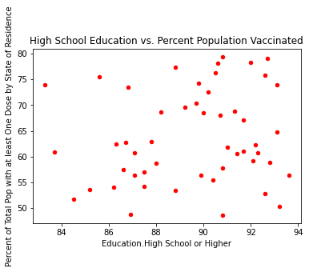

|  | Education.High School or Higher | Percent of Total Pop with at least One Dose by State of Residence |
| --- | --- | --- |
| Education.High School or Higher | 1.000000 | 0.147417 |
| Percent of Total Pop with at least One Dose by State of Residence | 0.147417 | 1.000000 |

```python
# create scatterplot to visualize relationship between high school education and percent of population that has been vaccinated
vaccine_education_df.plot(kind = "scatter", x = 'Education.High School or Higher', y = 'Percent of Total Pop with at least One Dose by State of Residence', color = 'red', title = "High School Education vs. Percent Population Vaccinated")
plt.show()
# calculate correlation for this relationship
hs_variables = ["Education.High School or Higher", 'Percent of Total Pop with at least One Dose by State of Residence']
vaccine_education_df[hs_variables].corr()
```

### High School Education Analysis

There is not a very strong correlation between high school education and the percent of the total population that has receivied at least one dose of a vaccine. The correlation is 0.147417, and the scatter plot shows only a slight positive correlation between these variables

# College Education vs. Vaccination Percentage:

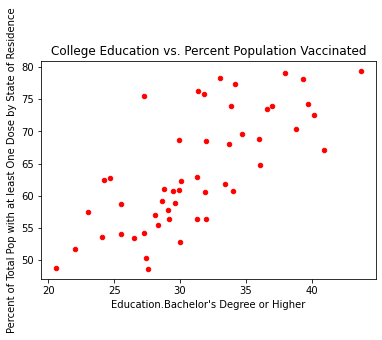

|  | Education.Bachelor's Degree or Higher | Percent of Total Pop with at least One Dose by State of Residence |
| --- | --- | --- |
| Education.Bachelor's Degree or Higher | 1.000000 | 0.729796 |
| Percent of Total Pop with at least One Dose by State of Residence | 0.729796 | 1.000000 |

```python
# create scatterplot to visualize relationship between college education and percent of population that has been vaccinated
vaccine_education_df.plot(kind = "scatter", x = "Education.Bachelor's Degree or Higher", y = 'Percent of Total Pop with at least One Dose by State of Residence', color = 'red', title = "College Education vs. Percent Population Vaccinated")
plt.show()
# calculate correlation for this relationship
college_variables = ["Education.Bachelor's Degree or Higher", 'Percent of Total Pop with at least One Dose by State of Residence']
vaccine_education_df[college_variables].corr()
```

### College Education Analysis

There is a strong positive correlation between having a bachelor's degree or higher and the percent of the total population that has received at least one dose of a vaccine. The correlation is 0.729796, and the scatter plot shows only a strong positive correlation between these variables. This indicates that states with highly educated populations may be more likely to have a larger percent of their poopulation vaccinated, despite there not being a correlation between high school graduation rates and the vaccination rates.

# Population Density vs. Vaccination Percentage:

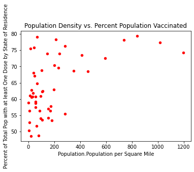

|  | Population.Population per Square Mile | Percent of Total Pop with at least One Dose by State of Residence |
| --- | --- | --- |
| Population.Population per Square Mile | 1.000000 | 0.542737 |
| Percent of Total Pop with at least One Dose by State of Residence | 0.542737 | 1.000000 |

```python
# Create scatterplot to visualize relationship between population density of a state and percent of population that has been vaccinated
vaccine_education_df.plot(kind = "scatter", x = 'Population.Population per Square Mile', y = 'Percent of Total Pop with at least One Dose by State of Residence', color = 'red', title = "Population Density vs. Percent Population Vaccinated")
plt.show()
# calculate correlation for this relationship
density_variables = ["Population.Population per Square Mile", 'Percent of Total Pop with at least One Dose by State of Residence']
vaccine_education_df[density_variables].corr()
```

### Population Denstiy Analysis

The Correlation between Population density and percent of the population with at least one dose is 0.542737 percent, which shows moderate correlation between the two variables.

# Under 18 Percentage vs Vaccine Percentage

[figure not shown]

|  | Age.Percent Under 18 Years | Percent of Total Pop with at least One Dose by State of Residence |
| --- | --- | --- |
| Age.Percent Under 18 Years | 1.000000 | -0.555766 |
| Percent of Total Pop with at least One Dose by State of Residence | -0.555766 | 1.000000 |

```python
# Create scatterplot to visualize relationship between population density of a state and percent of population that has been vaccinated
vaccine_education_df.plot(kind = "scatter", x = 'Age.Percent Under 18 Years', y = 'Percent of Total Pop with at least One Dose by State of Residence', color = 'red', title = "Population Density vs. Percent Population Vaccinated")
plt.show()
# calculate correlation for this relationship
density_variables = ["Age.Percent Under 18 Years", 'Percent of Total Pop with at least One Dose by State of Residence']
vaccine_education_df[density_variables].corr()
```

### Under 18 Percentage Analysis

The correlation between the percent of the state population under 18 years old and the percent of the population with at least one vaccination is negative 0.555766. This tells us that there is a moderate negative correlation between having a young population and being vaccinated, which means that states with younger populations have a lower vaccination rate. This could be due to older populations having a higher risk associated with COVID-19, which is a factor that can convince people to get the vaccine. Another factor in this may be that older populations had access to the vaccine much earlier than younger populations.

# Future Modeling

We plan to continue exploring different socioeconomic factors vs vaccine percentages in order to find what factors are most statistically significant in determining vaccination percentage. The vaccine percentage will be the dependent variable in all of the sets we compare it to. We also plan to apply these same comparisons to county level data to see if our findings continue to hold at the county level. We will also be looking at data for other vaccines as well and seeing if they have similar factors in their rates and if lower COVID-19 vaccination rates correspond to lower rates of other vaccinations.